# Predicting Life Expectancy: How long people live? Why? Why not?

STAT 420, Summer 2020

Venslaus Prakash Arokiaraj (netid: vpa2) & Pushpit Saxena(netid: pushpit2)

July 18th, 2020

## Team Information

- Name: **team_bbg**
- Size: **`2`**
- Details:

| Member Name | Member NetId |
| --- | --- |
| Pushpit Saxena | `pushpit2` |
| Venslaus Prakash Arokiaraj | `vpa2` |

## Introduction

This project will mainly focus on studying different factors that play statistically significant role in influencing **Life Expectancy**. We will be focusing on a wide variety of factors such as economic factors, social factors, health services factors (like immunizzation levels), mortality rate and various other health related factors that influence life expectancy.

## Dataset Information

Based on the description of the dataset on [kaggle](https://www.kaggle.com/kumarajarshi/life-expectancy-who), the Global Health Observatory(**GHO**) data repository under World Health Organization (**WHO**) keeps track of the health status as well as many other related factors for all countries. The datasets are made available to public for the purpose of health data analysis. This datset was collected from WHO and United Nations website and then the individual data files have been combined into a single data set (read more [here](https://www.kaggle.com/kumarajarshi/life-expectancy-who#Description))

## Data fields

Following are some of the important variables used in this dataset:

- **`Country`** (String): Country of observation
- **`Year`** (Integer): Year of observation
- **`Status`** (String): Whether the country of observation is developed or developing.
- **`Life expectancy`** (Decimal): Life expectancy in age
- **`Adult Mortality`** (Integer): Adult Mortality Rates of both sexes (probability of dying between 15 and 60 years per 1000 population)
- **`Infant deaths`** (Integer): Number of Infant Deaths per 1000 population
- **`Alcohol`** (Decimal): Alcohol, recorded per capita (15+) consumption (in litres of pure alcohol)
- **`Percentage Expenditure`** (Decimal): Expenditure on health as a percentage of Gross Domestic Product per capita(%)
- **`Hepatitis B`** (Int): Hepatitis B (HepB) immunization coverage among 1-year-olds (%)
- **`Measles`** (Int): Measles - number of reported cases per 1000 population
- **`BMI`** (Decimal): Average Body Mass Index of entire population
- **`Under-five deaths`** (Int): Number of under-five deaths per 1000 population
- **`Polio`** (Int): Polio (Pol3) immunization coverage among 1-year-olds (%)
- **`Total expenditure`** (Decimal): General government expenditure on health as a percentage of total government expenditure (%)
- **`Diphtheria`** (Int): Diphtheria tetanus toxoid and pertussis (DTP3) immunization coverage among 1-year-olds (%)
- **`HIV/AIDS`** (Decimal): Deaths per 1 000 live births HIV/AIDS (0-4 years)
- **`GDP`** (Decimal): Gross Domestic Product per capita (in USD)
- **`Population`** (Int): Population of the country

## Goals of the model

- From a research standpoint, one of the primary reason for us to pick this dataset is the size as well as variety of predictors that are available. We believe that this dataset is perfect for us to practice and implement majority of the techniques we have learned as part of the course and get a hands-on experience on a real life dataset.
- From larger perspective of data exploration and using data science to address real world issues, this dataset gives us an opportunity to try and answer some of the most important questions the human race is facing, like various factors affecting the longevity of life. As we briefly mentioned in our project description, we are interested in determining different factors which contributes to lower the value of life expectancy. Particularly, in this dataset as the observations are based on different countries, if we are able to find a good model than we can answer questions like what a country needs to focus on in order to have better life expectancy.

# Methods and Results

## Data Cleaning:

**Loading the Data:**

```r
raw_data <- read.csv("LifeExpectancyData.csv")

# Added Continent
raw_data$Continent <- countrycode(sourcevar = raw_data[, "Country"],
                              origin = "country.name",
                              destination = "continent")
# Added Region
raw_data$region <- countrycode(sourcevar = raw_data[, "Country"],
                              origin = "country.name",
                              destination = "region")
```

**Changing the names of the fields to follow a more consistent pattern(snake-case):**

```r
col_names <- tolower(trimws(str_replace_all(colnames(raw_data), "\\.+", "_")))
# col_names <- tolower(str_replace_all(colnames(raw_data), "\\s+", ""))
colnames(raw_data) <- col_names
```

**Snippet of the raw dataset:**

```r
tibble::as.tibble(raw_data)
```

```
## # A tibble: 2,938 x 24
##    country year  status life_expectancy adult_mortality infant_deaths alcohol
##    <fct>   <fct> <fct>            <dbl>           <int>         <int>   <dbl>
##  1 Afghan~ 2015  Devel~            65               263            62    0.01
##  2 Afghan~ 2014  Devel~            59.9             271            64    0.01
##  3 Afghan~ 2013  Devel~            59.9             268            66    0.01
##  4 Afghan~ 2012  Devel~            59.5             272            69    0.01
##  5 Afghan~ 2011  Devel~            59.2             275            71    0.01
##  6 Afghan~ 2010  Devel~            58.8             279            74    0.01
##  7 Afghan~ 2009  Devel~            58.6             281            77    0.01
##  8 Afghan~ 2008  Devel~            58.1             287            80    0.03
##  9 Afghan~ 2007  Devel~            57.5             295            82    0.02
## 10 Afghan~ 2006  Devel~            57.3             295            84    0.03
## # ... with 2,928 more rows, and 17 more variables:
## #   percentage_expenditure <dbl>, hepatitis_b <int>, measles <int>, bmi <dbl>,
## #   under_five_deaths <int>, polio <int>, total_expenditure <dbl>,
## #   diphtheria <int>, hiv_aids <dbl>, gdp <dbl>, population <dbl>,
## #   thinness_1_19_years <dbl>, thinness_5_9_years <dbl>,
## #   income_composition_of_resources <dbl>, schooling <dbl>, continent <fct>,
## #   region <fct>
```

**Summary of `numeric` fields:**

|  | Min. | 1st Qu. | Median | Mean | 3rd Qu. | Max. | NA’s |
| --- | --- | --- | --- | --- | --- | --- | --- |
| life_expectancy | 36.30 | 63.10 | 72.10 | 69.22 | 75.70 | 89.00 | 10.0 |
| adult_mortality | 1.00 | 74.00 | 144.00 | 164.80 | 228.00 | 723.00 | 10.0 |
| infant_deaths | 0.00 | 0.00 | 3.00 | 30.30 | 22.00 | 1800.00 | 0.0 |
| alcohol | 0.01 | 0.88 | 3.76 | 4.60 | 7.70 | 17.87 | 194.0 |
| percentage_expenditure | 0.00 | 4.69 | 64.91 | 738.25 | 441.53 | 19479.91 | 0.0 |
| hepatitis_b | 1.00 | 77.00 | 92.00 | 80.94 | 97.00 | 99.00 | 553.0 |
| measles | 0.00 | 0.00 | 17.00 | 2419.59 | 360.25 | 212183.00 | 0.0 |
| bmi | 1.00 | 19.30 | 43.50 | 38.32 | 56.20 | 87.30 | 34.0 |
| under_five_deaths | 0.00 | 0.00 | 4.00 | 42.04 | 28.00 | 2500.00 | 0.0 |
| polio | 3.00 | 78.00 | 93.00 | 82.55 | 97.00 | 99.00 | 19.0 |
| total_expenditure | 0.37 | 4.26 | 5.76 | 5.94 | 7.49 | 17.60 | 226.0 |
| diphtheria | 2.00 | 78.00 | 93.00 | 82.32 | 97.00 | 99.00 | 19.0 |
| hiv_aids | 0.10 | 0.10 | 0.10 | 1.74 | 0.80 | 50.60 | 0.1 |
| gdp | 1.68 | 463.94 | 1766.95 | 7483.16 | 5910.81 | 119172.74 | 448.0 |
| population | 34.00 | 195793.25 | 1386542.00 | 12753375.12 | 7420359.00 | 1293859294.00 | 652.0 |
| thinness_1_19_years | 0.10 | 1.60 | 3.30 | 4.84 | 7.20 | 27.70 | 34.0 |
| thinness_5_9_years | 0.10 | 1.50 | 3.30 | 4.87 | 7.20 | 28.60 | 34.0 |
| income_composition_of_resources | 0.00 | 0.49 | 0.68 | 0.63 | 0.78 | 0.95 | 167.0 |
| schooling | 0.00 | 10.10 | 12.30 | 11.99 | 14.30 | 20.70 | 163.0 |

We can see that only `10` observations have missing values for the response field `life_expectancy`, so we drop those `10` observations as dropping them will not make much difference to the models that we will try.

```r
mod_data_df <- raw_data[!is.na(raw_data$life_expectancy),]
nrow(mod_data_df)
```

```
## [1] 2928
```

There are still 1279 observations with some missing values. We will use the mean of the value for a given `country` to impute some of these values:

```r
new_df <- mod_data_df %>% group_by(country) %>% mutate_if(is.numeric,
                                              function(x) ifelse(is.na(x), mean(x, na.rm = TRUE), x))
nrow(new_df[!complete.cases(new_df),])
```

```
## [1] 800
```

Still there are some observations with missing values. Next we will use the mean of the values for a given `region` in a particular `year` to impute some of these missing values:

```r
cleaned_df <- as.data.frame(new_df %>% group_by(region, year) %>% mutate_if(is.numeric,
                                              function(x) ifelse(is.na(x), mean(x, na.rm = TRUE), x)) %>% ungroup)
cleaned_df$region <- as.factor(cleaned_df$region)
cleaned_df$year <- as.factor(cleaned_df$year)
nrow(cleaned_df[!complete.cases(cleaned_df),])
```

```
## [1] 0
```

Finally, we have imputed all the values and our final dataset has `2928` observations

## Data exploration and visualization

- Basic statistics (by region)

| Region | #Records | Avg. Life Expectancy | Avg. Infant Deaths | Avg. Adult Deaths |
| --- | --- | --- | --- | --- |
| East Asia & Pacific | 422 | 71.34231 | 25.265403 | 137.62260 |
| Europe & Central Asia | 770 | 75.95456 | 2.724675 | 109.26432 |
| Latin America & Caribbean | 498 | 73.07319 | 7.339357 | 135.32661 |
| Middle East & North Africa | 320 | 73.16312 | 11.281250 | 105.65625 |
| North America | 32 | 79.87500 | 14.093750 | 61.40625 |
| South Asia | 128 | 67.37422 | 250.039062 | 164.50781 |
| Sub-Saharan Africa | 768 | 57.08685 | 47.593750 | 283.07812 |

```
##   continent count mean_life_expectancy mean_infant_deaths mean_adult_deaths
## 1    Africa   864                57.80          44.246528         266.57176
## 2  Americas   530                73.90           7.747170         130.84659
## 3      Asia   752                72.55          60.875000         133.43750
## 4    Europe   626                77.80           1.172524          98.01282
## 5   Oceania   166                69.40           1.120482         135.08750
```

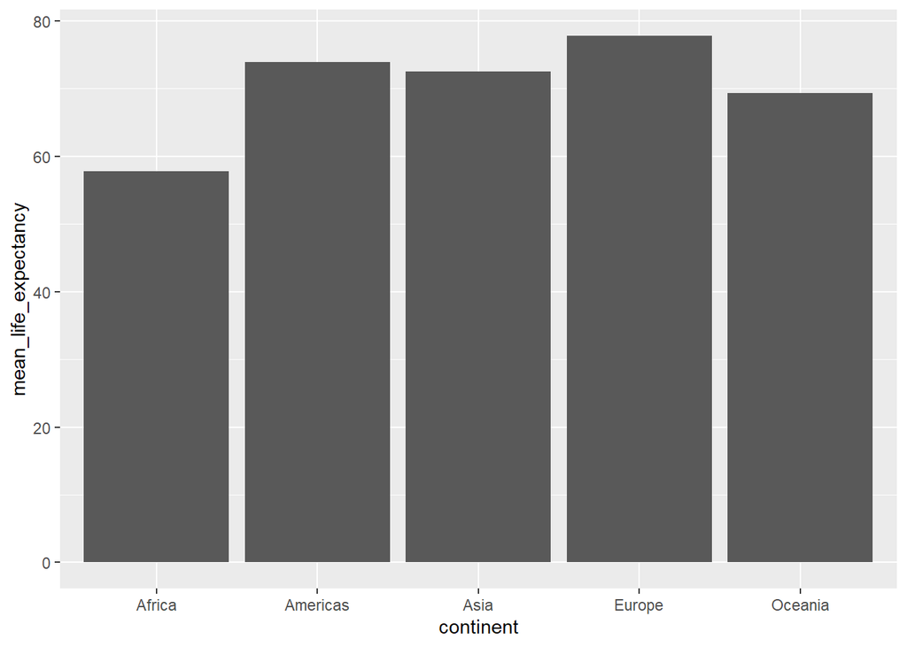

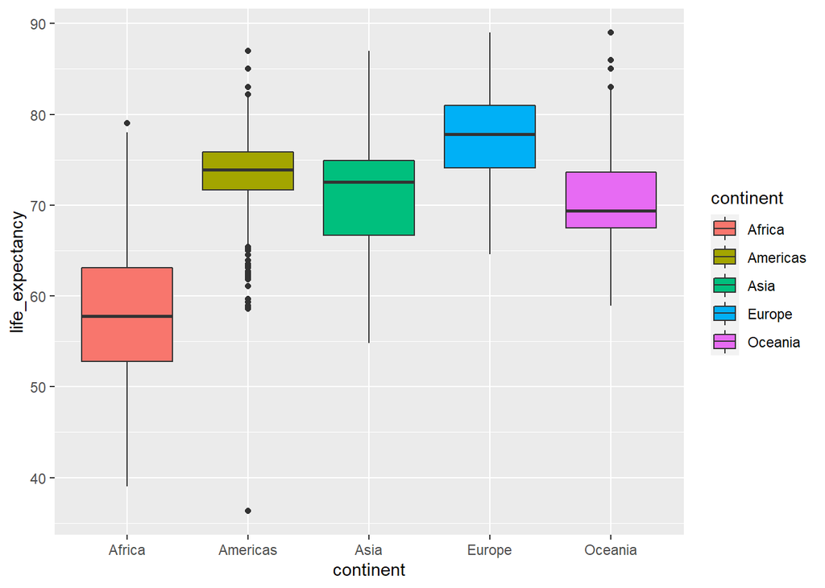

```
##                                 life_expectancy adult_mortality infant_deaths
## life_expectancy                             1.0            -0.7          -0.2
## adult_mortality                            -0.7             1.0           0.0
## infant_deaths                              -0.2             0.0           1.0
## alcohol                                     0.4            -0.2          -0.1
## percentage_expenditure                      0.4            -0.2          -0.1
## hepatitis_b                                 0.2            -0.1          -0.2
## measles                                    -0.1             0.0           0.5
## bmi                                         0.5            -0.4          -0.2
## under_five_deaths                          -0.2             0.1           1.0
## polio                                       0.3            -0.2          -0.2
## total_expenditure                           0.2            -0.1          -0.1
## diphtheria                                  0.3            -0.2          -0.2
## hiv_aids                                   -0.6             0.6           0.0
## gdp                                         0.4            -0.3          -0.1
## population                                  0.0             0.0           0.7
## thinness_1_19_years                        -0.5             0.3           0.5
## thinness_5_9_years                         -0.5             0.3           0.5
## income_composition_of_resources             0.7            -0.4          -0.1
## schooling                                   0.7            -0.4          -0.2
##                                 alcohol percentage_expenditure hepatitis_b
## life_expectancy                     0.4                    0.4         0.2
## adult_mortality                    -0.2                   -0.2        -0.1
## infant_deaths                      -0.1                   -0.1        -0.2
## alcohol                             1.0                    0.4         0.1
## percentage_expenditure              0.4                    1.0         0.0
## hepatitis_b                         0.1                    0.0         1.0
## measles                            -0.1                   -0.1        -0.1
## bmi                                 0.4                    0.2         0.1
## under_five_deaths                  -0.1                   -0.1        -0.2
## polio                               0.2                    0.1         0.5
## total_expenditure                   0.2                    0.2         0.1
## diphtheria                          0.2                    0.1         0.6
## hiv_aids                            0.0                   -0.1        -0.1
## gdp                                 0.4                    1.0         0.0
## population                          0.0                    0.0        -0.1
## thinness_1_19_years                -0.4                   -0.3        -0.1
## thinness_5_9_years                 -0.4                   -0.3        -0.1
## income_composition_of_resources     0.6                    0.4         0.2
## schooling                           0.6                    0.4         0.2
```

[output cut: 85 more lines]

```
## percentage_expenditure                                      0.4       0.4
## hepatitis_b                                                 0.2       0.2
## measles                                                    -0.1      -0.1
## bmi                                                         0.5       0.6
## under_five_deaths                                          -0.1      -0.2
## polio                                                       0.3       0.4
## total_expenditure                                           0.2       0.2
## diphtheria                                                  0.3       0.4
## hiv_aids                                                   -0.2      -0.2
## gdp                                                         0.4       0.5
## population                                                  0.0       0.0
## thinness_1_19_years                                        -0.5      -0.5
## thinness_5_9_years                                         -0.4      -0.5
## income_composition_of_resources                             1.0       0.8
## schooling                                                   0.8       1.0
```

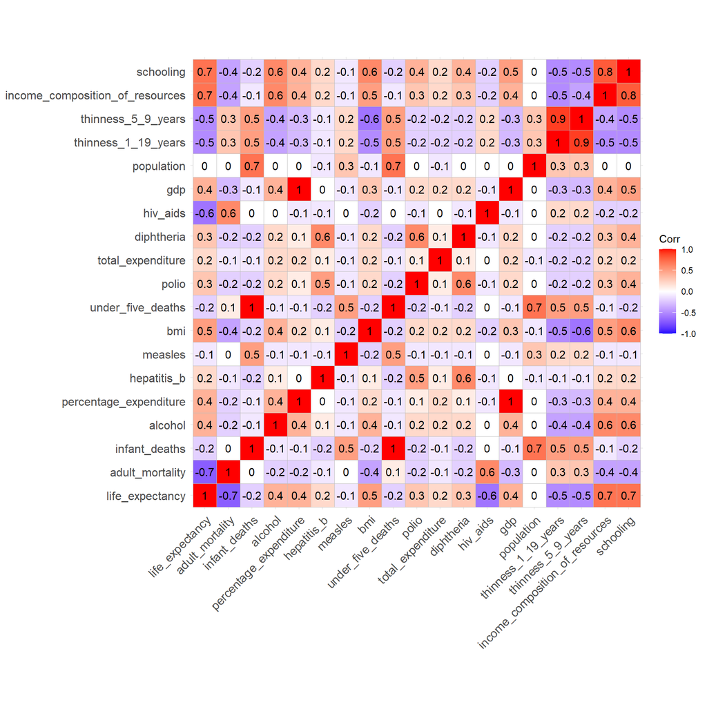

# Model Building

**Splitting the data in training and test set (`90%` training, `10%` hold out test set):

```r
set.seed(19851115)
le_trn_data_idx  <- sample(nrow(cleaned_df), size = trunc(0.90 * nrow(cleaned_df)))
le_trn_data <- cleaned_df[le_trn_data_idx, ]
le_tst_data <- cleaned_df[-le_trn_data_idx, ]
```

Ignoring all the categorical variables for now (except `status`, we have fitted models using some of these categorical variables but couldn’t get better results, code can be seen in Appendix)

```r
non_cat_predictor_df <- subset(le_trn_data, select = -c(year, country, continent, region))
```

Full Additive model (with all the numerical predictor and `status`)

```r
full_additve_model <- lm(life_expectancy ~ ., data = non_cat_predictor_df)
summary(full_additve_model)
```

```
##
## Call:
## lm(formula = life_expectancy ~ ., data = non_cat_predictor_df)
##
## Residuals:
##      Min       1Q   Median       3Q      Max
## -21.6482  -2.2808  -0.1263   2.2784  17.4919
##
## Coefficients:
##                                   Estimate Std. Error t value Pr(>|t|)
## (Intercept)                      5.521e+01  6.664e-01  82.838  < 2e-16 ***
## statusDeveloping                -1.243e+00  2.834e-01  -4.386 1.20e-05 ***
## adult_mortality                 -1.818e-02  8.274e-04 -21.975  < 2e-16 ***
## infant_deaths                    9.078e-02  8.753e-03  10.371  < 2e-16 ***
## alcohol                          3.047e-02  2.696e-02   1.130   0.2585
## percentage_expenditure           1.562e-04  7.757e-05   2.014   0.0441 *
## hepatitis_b                     -2.051e-03  4.082e-03  -0.502   0.6155
## measles                         -1.497e-05  7.809e-06  -1.917   0.0553 .
## bmi                              3.719e-02  5.170e-03   7.192 8.27e-13 ***
## under_five_deaths               -6.775e-02  6.406e-03 -10.575  < 2e-16 ***
## polio                            2.547e-02  4.731e-03   5.384 7.92e-08 ***
## total_expenditure                1.127e-02  3.447e-02   0.327   0.7437
## diphtheria                       3.305e-02  5.048e-03   6.547 7.04e-11 ***
## hiv_aids                        -4.746e-01  1.777e-02 -26.709  < 2e-16 ***
## gdp                              2.965e-05  1.195e-05   2.481   0.0132 *
## population                       6.525e-10  1.900e-09   0.343   0.7313
## thinness_1_19_years             -7.204e-02  4.970e-02  -1.449   0.1473
## thinness_5_9_years              -7.721e-03  4.899e-02  -0.158   0.8748
## income_composition_of_resources  6.297e+00  6.552e-01   9.611  < 2e-16 ***
## schooling                        7.378e-01  4.511e-02  16.355  < 2e-16 ***
## ---
## Signif. codes:  0 '***' 0.001 '**' 0.01 '*' 0.05 '.' 0.1 ' ' 1
##
## Residual standard error: 3.959 on 2615 degrees of freedom
## Multiple R-squared:  0.828,  Adjusted R-squared:  0.8267
## F-statistic: 662.3 on 19 and 2615 DF,  p-value: < 2.2e-16
```

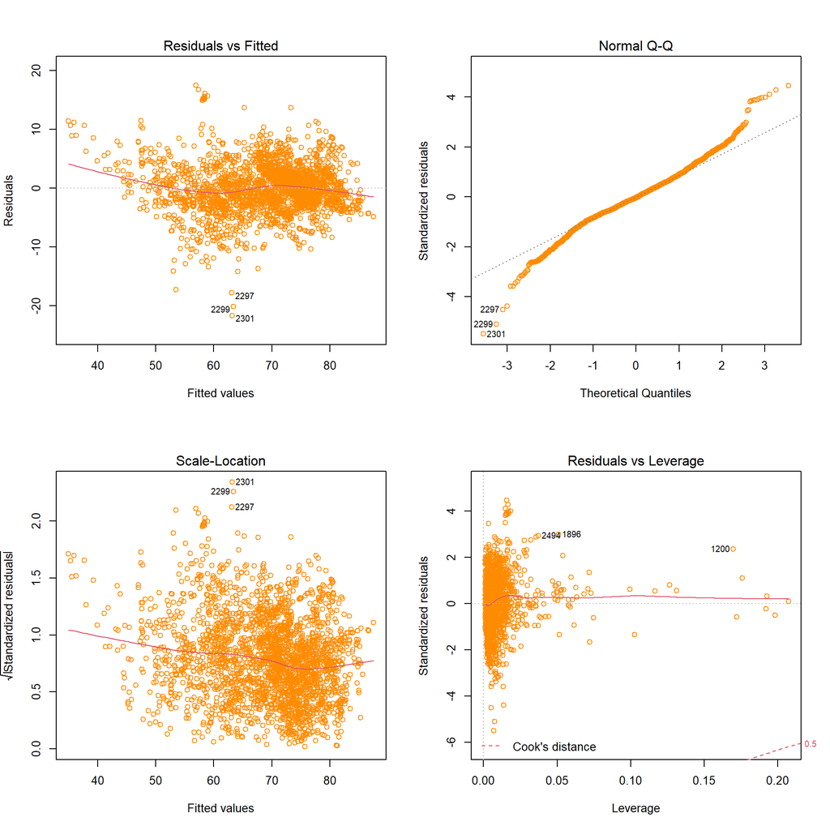

```r
par(mfrow = c(2, 2))
plot(full_additve_model, col="darkorange", )
```

```r
shapiro.test(resid(full_additve_model))
```

```
##
##  Shapiro-Wilk normality test
##
## data:  resid(full_additve_model)
## W = 0.98083, p-value < 2.2e-16
```

```r
calc_rmse(le_tst_data$life_expectancy,
          predict(full_additve_model, newdata = le_tst_data))
```

```
## [1] 3.745306
```

Removing some of the least significant predictors:

infant deat v. under_5_deaths

```r
sig_linear_model <- lm(life_expectancy ~  adult_mortality +
                         under_five_deaths + bmi + diphtheria + hiv_aids + gdp +
                         income_composition_of_resources * status  + schooling,
                       data = non_cat_predictor_df)
summary(sig_linear_model)
```

```
##
## Call:
## lm(formula = life_expectancy ~ adult_mortality + under_five_deaths +
##     bmi + diphtheria + hiv_aids + gdp + income_composition_of_resources *
##     status + schooling, data = non_cat_predictor_df)
##
## Residuals:
##      Min       1Q   Median       3Q      Max
## -22.0007  -2.2708  -0.0978   2.3975  18.9066
##
## Coefficients:
##                                                    Estimate Std. Error t value
## (Intercept)                                       4.612e+01  3.062e+00  15.064
## adult_mortality                                  -1.861e-02  8.426e-04 -22.081
## under_five_deaths                                -2.447e-03  5.363e-04  -4.563
## bmi                                               4.427e-02  4.986e-03   8.877
## diphtheria                                        5.412e-02  3.812e-03  14.198
## hiv_aids                                         -4.909e-01  1.803e-02 -27.219
## gdp                                               4.058e-05  7.454e-06   5.444
## income_composition_of_resources                   1.676e+01  3.701e+00   4.529
## statusDeveloping                                  6.676e+00  3.036e+00   2.199
## schooling                                         7.760e-01  4.476e-02  17.336
## income_composition_of_resources:statusDeveloping -9.639e+00  3.626e+00  -2.658
##                                                  Pr(>|t|)
## (Intercept)                                       < 2e-16 ***
## adult_mortality                                   < 2e-16 ***
## under_five_deaths                                5.28e-06 ***
## bmi                                               < 2e-16 ***
## diphtheria                                        < 2e-16 ***
## hiv_aids                                          < 2e-16 ***
## gdp                                              5.70e-08 ***
## income_composition_of_resources                  6.19e-06 ***
## statusDeveloping                                   0.0280 *
## schooling                                         < 2e-16 ***
## income_composition_of_resources:statusDeveloping   0.0079 **
## ---
## Signif. codes:  0 '***' 0.001 '**' 0.01 '*' 0.05 '.' 0.1 ' ' 1
##
## Residual standard error: 4.07 on 2624 degrees of freedom
## Multiple R-squared:  0.8175, Adjusted R-squared:  0.8168
## F-statistic:  1175 on 10 and 2624 DF,  p-value: < 2.2e-16
```

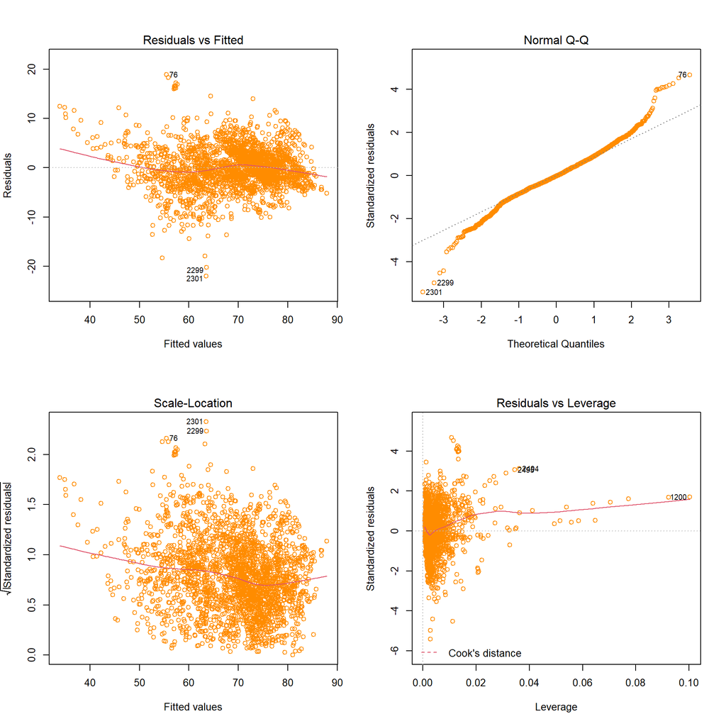

```r
par(mfrow = c(2, 2))
plot(sig_linear_model, col="darkorange", )
```

```r
calc_rmse(le_tst_data$life_expectancy,
          predict(sig_linear_model, newdata = le_tst_data))
```

```
## [1] 3.908733
```

```r
sig_linear_model <- lm(life_expectancy ~  adult_mortality +
                         under_five_deaths + bmi * status + diphtheria + hiv_aids + gdp * status +
                         income_composition_of_resources * status  + schooling * status,
                       data = non_cat_predictor_df)
summary(sig_linear_model)
```

```
##
## Call:
## lm(formula = life_expectancy ~ adult_mortality + under_five_deaths +
##     bmi * status + diphtheria + hiv_aids + gdp * status + income_composition_of_resources *
##     status + schooling * status, data = non_cat_predictor_df)
##
## Residuals:
##     Min      1Q  Median      3Q     Max
## -21.764  -2.216  -0.118   2.282  19.188
##
## Coefficients:
##                                                    Estimate Std. Error t value
## (Intercept)                                       4.247e+01  3.191e+00  13.310
## adult_mortality                                  -1.798e-02  8.321e-04 -21.605
## under_five_deaths                                -2.118e-03  5.294e-04  -4.001
## bmi                                              -1.539e-02  1.099e-02  -1.401
## statusDeveloping                                  1.001e+01  3.178e+00   3.152
## diphtheria                                        5.245e-02  3.771e-03  13.908
## hiv_aids                                         -4.895e-01  1.776e-02 -27.556
## gdp                                               3.057e-06  9.917e-06   0.308
## income_composition_of_resources                   4.098e+01  5.125e+00   7.996
## schooling                                        -4.364e-02  1.535e-01  -0.284
## bmi:statusDeveloping                              7.229e-02  1.229e-02   5.880
## statusDeveloping:gdp                              6.276e-05  1.509e-05   4.160
## statusDeveloping:income_composition_of_resources -3.495e+01  5.164e+00  -6.768
## statusDeveloping:schooling                        8.537e-01  1.609e-01   5.306
##                                                  Pr(>|t|)
## (Intercept)                                       < 2e-16 ***
## adult_mortality                                   < 2e-16 ***
## under_five_deaths                                6.49e-05 ***
## bmi                                               0.16145
## statusDeveloping                                  0.00164 **
## diphtheria                                        < 2e-16 ***
## hiv_aids                                          < 2e-16 ***
## gdp                                               0.75789
## income_composition_of_resources                  1.91e-15 ***
## schooling                                         0.77618
## bmi:statusDeveloping                             4.61e-09 ***
## statusDeveloping:gdp                             3.28e-05 ***
## statusDeveloping:income_composition_of_resources 1.61e-11 ***
## statusDeveloping:schooling                       1.22e-07 ***
## ---
## Signif. codes:  0 '***' 0.001 '**' 0.01 '*' 0.05 '.' 0.1 ' ' 1
##
## Residual standard error: 4.006 on 2621 degrees of freedom
## Multiple R-squared:  0.8234, Adjusted R-squared:  0.8225
## F-statistic:   940 on 13 and 2621 DF,  p-value: < 2.2e-16
```

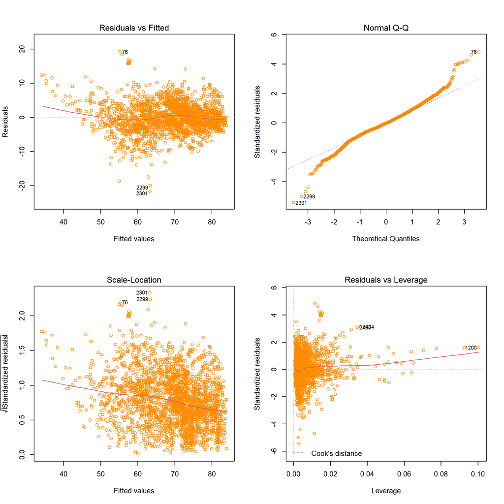

```r
par(mfrow = c(2, 2))
plot(sig_linear_model, col="darkorange", )
```

```r
calc_rmse(le_tst_data$life_expectancy,
          predict(sig_linear_model, newdata = le_tst_data))
```

```
## [1] 3.844726
```

```r
aic_model_backward <- step(sig_linear_model, direction = "backward")
```

```
## Start:  AIC=7328.11
## life_expectancy ~ adult_mortality + under_five_deaths + bmi *
##     status + diphtheria + hiv_aids + gdp * status + income_composition_of_resources *
##     status + schooling * status
##
##                                          Df Sum of Sq   RSS    AIC
## <none>                                                42069 7328.1
## - under_five_deaths                       1     256.9 42326 7342.1
## - status:gdp                              1     277.8 42347 7343.4
## - status:schooling                        1     451.9 42521 7354.3
## - bmi:status                              1     555.0 42624 7360.6
## - status:income_composition_of_resources  1     735.2 42805 7371.8
## - diphtheria                              1    3104.7 45174 7513.7
## - adult_mortality                         1    7492.2 49562 7758.0
## - hiv_aids                                1   12187.9 54257 7996.5
```

```r
summary(aic_model_backward)
```

```
##
## Call:
## lm(formula = life_expectancy ~ adult_mortality + under_five_deaths +
##     bmi * status + diphtheria + hiv_aids + gdp * status + income_composition_of_resources *
##     status + schooling * status, data = non_cat_predictor_df)
##
## Residuals:
##     Min      1Q  Median      3Q     Max
## -21.764  -2.216  -0.118   2.282  19.188
##
## Coefficients:
##                                                    Estimate Std. Error t value
## (Intercept)                                       4.247e+01  3.191e+00  13.310
## adult_mortality                                  -1.798e-02  8.321e-04 -21.605
## under_five_deaths                                -2.118e-03  5.294e-04  -4.001
## bmi                                              -1.539e-02  1.099e-02  -1.401
## statusDeveloping                                  1.001e+01  3.178e+00   3.152
## diphtheria                                        5.245e-02  3.771e-03  13.908
## hiv_aids                                         -4.895e-01  1.776e-02 -27.556
## gdp                                               3.057e-06  9.917e-06   0.308
## income_composition_of_resources                   4.098e+01  5.125e+00   7.996
## schooling                                        -4.364e-02  1.535e-01  -0.284
## bmi:statusDeveloping                              7.229e-02  1.229e-02   5.880
## statusDeveloping:gdp                              6.276e-05  1.509e-05   4.160
## statusDeveloping:income_composition_of_resources -3.495e+01  5.164e+00  -6.768
## statusDeveloping:schooling                        8.537e-01  1.609e-01   5.306
##                                                  Pr(>|t|)
## (Intercept)                                       < 2e-16 ***
## adult_mortality                                   < 2e-16 ***
## under_five_deaths                                6.49e-05 ***
## bmi                                               0.16145
## statusDeveloping                                  0.00164 **
## diphtheria                                        < 2e-16 ***
## hiv_aids                                          < 2e-16 ***
## gdp                                               0.75789
## income_composition_of_resources                  1.91e-15 ***
## schooling                                         0.77618
## bmi:statusDeveloping                             4.61e-09 ***
## statusDeveloping:gdp                             3.28e-05 ***
## statusDeveloping:income_composition_of_resources 1.61e-11 ***
## statusDeveloping:schooling                       1.22e-07 ***
## ---
## Signif. codes:  0 '***' 0.001 '**' 0.01 '*' 0.05 '.' 0.1 ' ' 1
##
## Residual standard error: 4.006 on 2621 degrees of freedom
## Multiple R-squared:  0.8234, Adjusted R-squared:  0.8225
## F-statistic:   940 on 13 and 2621 DF,  p-value: < 2.2e-16
```

```r
par(mfrow = c(2, 2))
plot(aic_model_backward, col="darkorange", )
```

[output not shown]

```r
calc_rmse(le_tst_data$life_expectancy,
          predict(aic_model_backward, newdata = le_tst_data))
```

```
## [1] 3.844726
```

```r
aic_model_both <- step(sig_linear_model, direction = "both")
```

```
## Start:  AIC=7328.11
## life_expectancy ~ adult_mortality + under_five_deaths + bmi *
##     status + diphtheria + hiv_aids + gdp * status + income_composition_of_resources *
##     status + schooling * status
##
##                                          Df Sum of Sq   RSS    AIC
## <none>                                                42069 7328.1
## - under_five_deaths                       1     256.9 42326 7342.1
## - status:gdp                              1     277.8 42347 7343.4
## - status:schooling                        1     451.9 42521 7354.3
## - bmi:status                              1     555.0 42624 7360.6
## - status:income_composition_of_resources  1     735.2 42805 7371.8
## - diphtheria                              1    3104.7 45174 7513.7
## - adult_mortality                         1    7492.2 49562 7758.0
## - hiv_aids                                1   12187.9 54257 7996.5
```

```r
summary(aic_model_both)
```

```
##
## Call:
## lm(formula = life_expectancy ~ adult_mortality + under_five_deaths +
##     bmi * status + diphtheria + hiv_aids + gdp * status + income_composition_of_resources *
##     status + schooling * status, data = non_cat_predictor_df)
##
## Residuals:
##     Min      1Q  Median      3Q     Max
## -21.764  -2.216  -0.118   2.282  19.188
##
## Coefficients:
##                                                    Estimate Std. Error t value
## (Intercept)                                       4.247e+01  3.191e+00  13.310
## adult_mortality                                  -1.798e-02  8.321e-04 -21.605
## under_five_deaths                                -2.118e-03  5.294e-04  -4.001
## bmi                                              -1.539e-02  1.099e-02  -1.401
## statusDeveloping                                  1.001e+01  3.178e+00   3.152
## diphtheria                                        5.245e-02  3.771e-03  13.908
## hiv_aids                                         -4.895e-01  1.776e-02 -27.556
## gdp                                               3.057e-06  9.917e-06   0.308
## income_composition_of_resources                   4.098e+01  5.125e+00   7.996
## schooling                                        -4.364e-02  1.535e-01  -0.284
## bmi:statusDeveloping                              7.229e-02  1.229e-02   5.880
## statusDeveloping:gdp                              6.276e-05  1.509e-05   4.160
## statusDeveloping:income_composition_of_resources -3.495e+01  5.164e+00  -6.768
## statusDeveloping:schooling                        8.537e-01  1.609e-01   5.306
##                                                  Pr(>|t|)
## (Intercept)                                       < 2e-16 ***
## adult_mortality                                   < 2e-16 ***
## under_five_deaths                                6.49e-05 ***
## bmi                                               0.16145
## statusDeveloping                                  0.00164 **
## diphtheria                                        < 2e-16 ***
## hiv_aids                                          < 2e-16 ***
## gdp                                               0.75789
## income_composition_of_resources                  1.91e-15 ***
## schooling                                         0.77618
## bmi:statusDeveloping                             4.61e-09 ***
## statusDeveloping:gdp                             3.28e-05 ***
## statusDeveloping:income_composition_of_resources 1.61e-11 ***
## statusDeveloping:schooling                       1.22e-07 ***
## ---
## Signif. codes:  0 '***' 0.001 '**' 0.01 '*' 0.05 '.' 0.1 ' ' 1
##
## Residual standard error: 4.006 on 2621 degrees of freedom
## Multiple R-squared:  0.8234, Adjusted R-squared:  0.8225
## F-statistic:   940 on 13 and 2621 DF,  p-value: < 2.2e-16
```

```r
par(mfrow = c(2, 2))
plot(aic_model_both, col="darkorange", )
```

[output not shown]

```r
calc_rmse(le_tst_data$life_expectancy,
          predict(aic_model_both, newdata = le_tst_data))
```

```
## [1] 3.844726
```

```r
bic_model_both <- step(sig_linear_model, k = log(length(resid(sig_linear_model))), direction = "both")
```

```
## Start:  AIC=7410.38
## life_expectancy ~ adult_mortality + under_five_deaths + bmi *
##     status + diphtheria + hiv_aids + gdp * status + income_composition_of_resources *
##     status + schooling * status
##
##                                          Df Sum of Sq   RSS    AIC
## <none>                                                42069 7410.4
## - under_five_deaths                       1     256.9 42326 7418.5
## - status:gdp                              1     277.8 42347 7419.8
## - status:schooling                        1     451.9 42521 7430.7
## - bmi:status                              1     555.0 42624 7437.0
## - status:income_composition_of_resources  1     735.2 42805 7448.2
## - diphtheria                              1    3104.7 45174 7590.1
## - adult_mortality                         1    7492.2 49562 7834.4
## - hiv_aids                                1   12187.9 54257 8072.9
```

```r
summary(bic_model_both)
```

```
##
## Call:
## lm(formula = life_expectancy ~ adult_mortality + under_five_deaths +
##     bmi * status + diphtheria + hiv_aids + gdp * status + income_composition_of_resources *
##     status + schooling * status, data = non_cat_predictor_df)
##
## Residuals:
##     Min      1Q  Median      3Q     Max
## -21.764  -2.216  -0.118   2.282  19.188
##
## Coefficients:
##                                                    Estimate Std. Error t value
## (Intercept)                                       4.247e+01  3.191e+00  13.310
## adult_mortality                                  -1.798e-02  8.321e-04 -21.605
## under_five_deaths                                -2.118e-03  5.294e-04  -4.001
## bmi                                              -1.539e-02  1.099e-02  -1.401
## statusDeveloping                                  1.001e+01  3.178e+00   3.152
## diphtheria                                        5.245e-02  3.771e-03  13.908
## hiv_aids                                         -4.895e-01  1.776e-02 -27.556
## gdp                                               3.057e-06  9.917e-06   0.308
## income_composition_of_resources                   4.098e+01  5.125e+00   7.996
## schooling                                        -4.364e-02  1.535e-01  -0.284
## bmi:statusDeveloping                              7.229e-02  1.229e-02   5.880
## statusDeveloping:gdp                              6.276e-05  1.509e-05   4.160
## statusDeveloping:income_composition_of_resources -3.495e+01  5.164e+00  -6.768
## statusDeveloping:schooling                        8.537e-01  1.609e-01   5.306
##                                                  Pr(>|t|)
## (Intercept)                                       < 2e-16 ***
## adult_mortality                                   < 2e-16 ***
## under_five_deaths                                6.49e-05 ***
## bmi                                               0.16145
## statusDeveloping                                  0.00164 **
## diphtheria                                        < 2e-16 ***
## hiv_aids                                          < 2e-16 ***
## gdp                                               0.75789
## income_composition_of_resources                  1.91e-15 ***
## schooling                                         0.77618
## bmi:statusDeveloping                             4.61e-09 ***
## statusDeveloping:gdp                             3.28e-05 ***
## statusDeveloping:income_composition_of_resources 1.61e-11 ***
## statusDeveloping:schooling                       1.22e-07 ***
## ---
## Signif. codes:  0 '***' 0.001 '**' 0.01 '*' 0.05 '.' 0.1 ' ' 1
##
## Residual standard error: 4.006 on 2621 degrees of freedom
## Multiple R-squared:  0.8234, Adjusted R-squared:  0.8225
## F-statistic:   940 on 13 and 2621 DF,  p-value: < 2.2e-16
```

```r
par(mfrow = c(2, 2))
plot(bic_model_both, col="darkorange", )
```

[output not shown]

```r
calc_rmse(le_tst_data$life_expectancy,
          predict(bic_model_both, newdata = le_tst_data))
```

```
## [1] 3.844726
```

```r
bc <- boxcox(sig_linear_model, lambda = seq(-3, 3))
```

[figure not shown]

```r
best.lam <- bc$x[which(bc$y==max(bc$y))]
```

```r
sig_linear_model_sq <- lm(life_expectancy ^ 2 ~ adult_mortality + alcohol + percentage_expenditure +
                         under_five_deaths + bmi + diphtheria + hiv_aids + gdp +
                         income_composition_of_resources  + schooling, data = non_cat_predictor_df)
summary(sig_linear_model_sq)
```

```
##
## Call:
## lm(formula = life_expectancy^2 ~ adult_mortality + alcohol +
##     percentage_expenditure + under_five_deaths + bmi + diphtheria +
##     hiv_aids + gdp + income_composition_of_resources + schooling,
##     data = non_cat_predictor_df)
##
## Residuals:
##      Min       1Q   Median       3Q      Max
## -2395.07  -331.27   -36.04   308.04  2517.91
##
## Coefficients:
##                                   Estimate Std. Error t value Pr(>|t|)
## (Intercept)                      2.642e+03  6.566e+01  40.239  < 2e-16 ***
## adult_mortality                 -2.545e+00  1.146e-01 -22.217  < 2e-16 ***
## alcohol                          1.270e+01  3.263e+00   3.892 0.000102 ***
## percentage_expenditure           3.302e-02  1.075e-02   3.073 0.002144 **
## under_five_deaths               -3.215e-01  7.287e-02  -4.411 1.07e-05 ***
## bmi                              5.461e+00  6.765e-01   8.073 1.03e-15 ***
## diphtheria                       6.531e+00  5.160e-01  12.656  < 2e-16 ***
## hiv_aids                        -5.685e+01  2.457e+00 -23.142  < 2e-16 ***
## gdp                              5.533e-03  1.658e-03   3.338 0.000856 ***
## income_composition_of_resources  9.926e+02  9.023e+01  11.000  < 2e-16 ***
## schooling                        1.071e+02  6.202e+00  17.264  < 2e-16 ***
## ---
## Signif. codes:  0 '***' 0.001 '**' 0.01 '*' 0.05 '.' 0.1 ' ' 1
##
## Residual standard error: 553 on 2624 degrees of freedom
## Multiple R-squared:  0.8096, Adjusted R-squared:  0.8088
## F-statistic:  1115 on 10 and 2624 DF,  p-value: < 2.2e-16
```

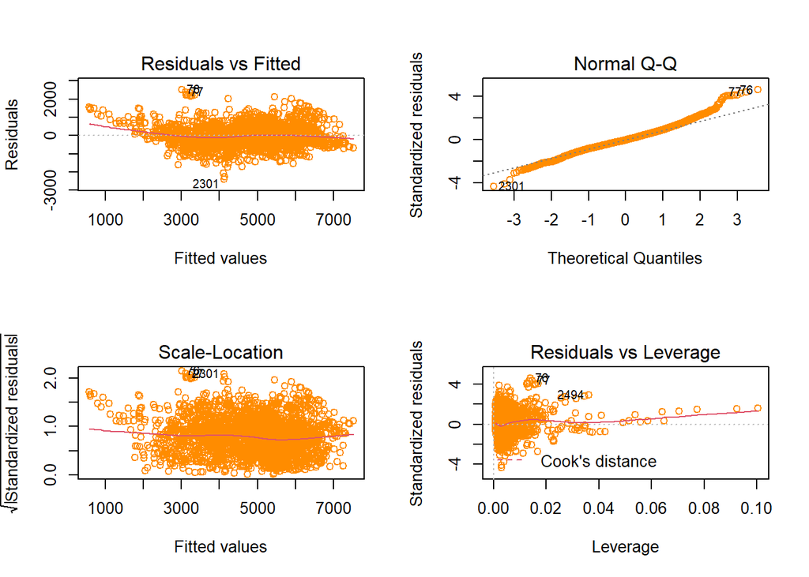

```r
par(mfrow = c(2, 2))
plot(sig_linear_model_sq, col="darkorange", )
```

```r
shapiro.test(resid(sig_linear_model_sq))
```

```
##
##  Shapiro-Wilk normality test
##
## data:  resid(sig_linear_model_sq)
## W = 0.98251, p-value < 2.2e-16
```

```r
calc_rmse(le_tst_data$life_expectancy,
          predict(sig_linear_model_sq, newdata = le_tst_data))
```

```
## [1] 4903.699
```

```r
aic_model <- step(sig_linear_model, direction = "both", test = "F")
```

```
## Start:  AIC=7328.11
## life_expectancy ~ adult_mortality + under_five_deaths + bmi *
##     status + diphtheria + hiv_aids + gdp * status + income_composition_of_resources *
##     status + schooling * status
##
##                                          Df Sum of Sq   RSS    AIC F value
## <none>                                                42069 7328.1
## - under_five_deaths                       1     256.9 42326 7342.1  16.007
## - status:gdp                              1     277.8 42347 7343.4  17.306
## - status:schooling                        1     451.9 42521 7354.3  28.152
## - bmi:status                              1     555.0 42624 7360.6  34.579
## - status:income_composition_of_resources  1     735.2 42805 7371.8  45.805
## - diphtheria                              1    3104.7 45174 7513.7 193.426
## - adult_mortality                         1    7492.2 49562 7758.0 466.774
## - hiv_aids                                1   12187.9 54257 7996.5 759.330
##                                             Pr(>F)
## <none>
## - under_five_deaths                      6.487e-05 ***
## - status:gdp                             3.284e-05 ***
## - status:schooling                       1.215e-07 ***
## - bmi:status                             4.613e-09 ***
## - status:income_composition_of_resources 1.606e-11 ***
## - diphtheria                             < 2.2e-16 ***
## - adult_mortality                        < 2.2e-16 ***
## - hiv_aids                               < 2.2e-16 ***
## ---
## Signif. codes:  0 '***' 0.001 '**' 0.01 '*' 0.05 '.' 0.1 ' ' 1
```

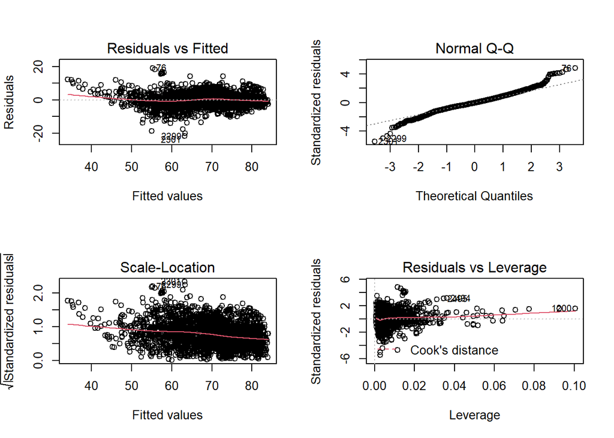

```r
par(mfrow = c(2, 2))
plot(aic_model)
```

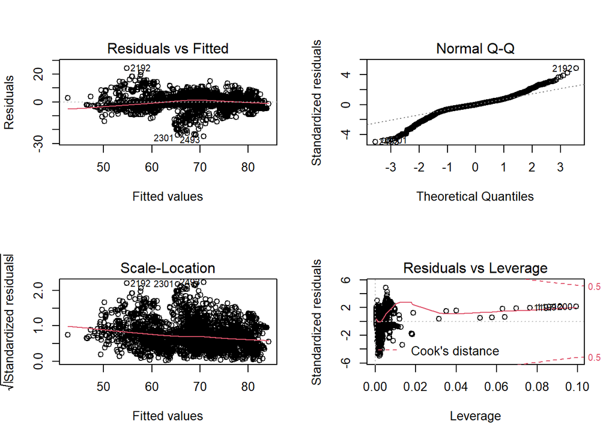

```r
lm_model <- lm(life_expectancy ~ income_composition_of_resources + adult_mortality +
                  bmi +  status + under_five_deaths,
               data = non_cat_predictor_df)
par(mfrow = c(2, 2))
plot(lm_model)
```

```r
calc_rmse(le_tst_data$life_expectancy,
          predict(lm_model, newdata = le_tst_data))
```

```
## [1] 4.766326
```

```r
bc <- boxcox(lm_model, lambda = seq(-3, 3))
```

[figure not shown]

```r
best.lam <- bc$x[which(bc$y==max(bc$y))]
```

```r
lm_model_cube <- lm(life_expectancy ^ 3 ~ income_composition_of_resources + adult_mortality +
                  bmi +  status + under_five_deaths,
               data = non_cat_predictor_df)
summary(lm_model_cube)
```

```
##
## Call:
## lm(formula = life_expectancy^3 ~ income_composition_of_resources +
##     adult_mortality + bmi + status + under_five_deaths, data = non_cat_predictor_df)
##
## Residuals:
##     Min      1Q  Median      3Q     Max
## -264191  -33656   -3659   31225  340598
##
## Coefficients:
##                                   Estimate Std. Error t value Pr(>|t|)
## (Intercept)                     281961.262   7959.723  35.424  < 2e-16 ***
## income_composition_of_resources 235398.426   8317.241  28.302  < 2e-16 ***
## adult_mortality                   -388.140     12.330 -31.478  < 2e-16 ***
## bmi                                989.076     79.225  12.484  < 2e-16 ***
## statusDeveloping                -61380.933   3979.585 -15.424  < 2e-16 ***
## under_five_deaths                  -53.334      8.747  -6.097 1.24e-09 ***
## ---
## Signif. codes:  0 '***' 0.001 '**' 0.01 '*' 0.05 '.' 0.1 ' ' 1
##
## Residual standard error: 67240 on 2629 degrees of freedom
## Multiple R-squared:  0.7294, Adjusted R-squared:  0.7289
## F-statistic:  1417 on 5 and 2629 DF,  p-value: < 2.2e-16
```

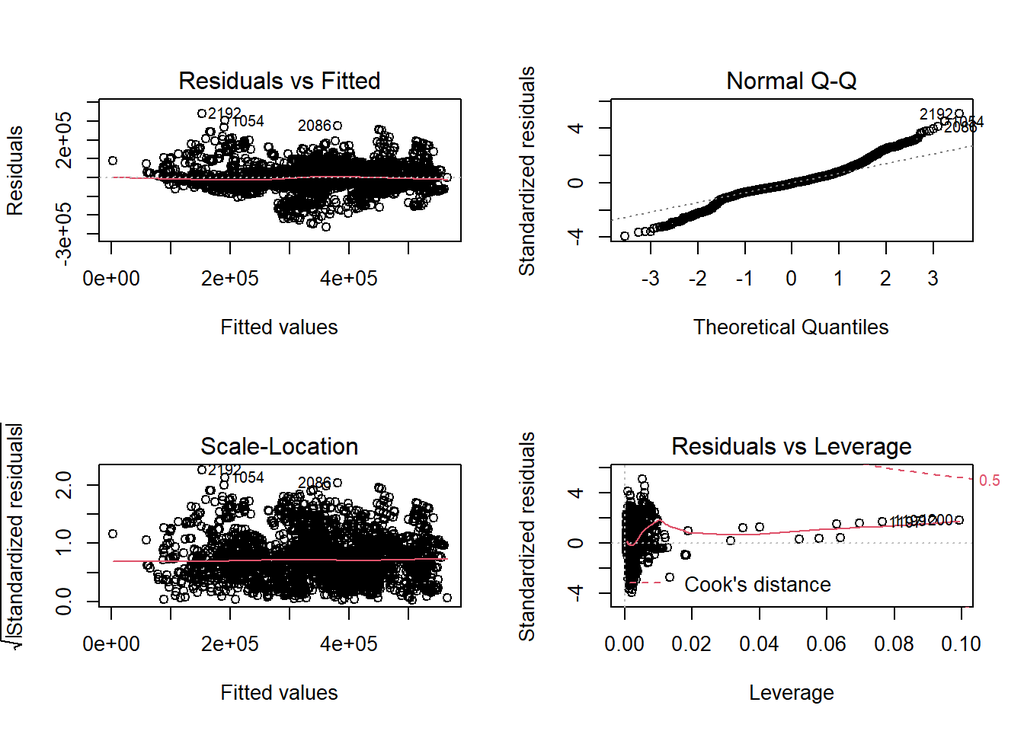

```r
par(mfrow = c(2, 2))
plot(lm_model_cube)
```

```r
calc_rmse(le_tst_data$life_expectancy,
          predict(lm_model_cube, newdata = le_tst_data))
```

```
## [1] 363332.2
```

```r
model1 <- lm(life_expectancy ~ schooling + bmi + alcohol + gdp + hiv_aids + diphtheria + status, data = non_cat_predictor_df)
summary(model1)
```

```
##
## Call:
## lm(formula = life_expectancy ~ schooling + bmi + alcohol + gdp +
##     hiv_aids + diphtheria + status, data = non_cat_predictor_df)
##
## Residuals:
##      Min       1Q   Median       3Q      Max
## -26.9508  -2.8516  -0.0173   2.8691  21.4125
##
## Coefficients:
##                    Estimate Std. Error t value Pr(>|t|)
## (Intercept)       4.884e+01  5.877e-01  83.102  < 2e-16 ***
## schooling         1.275e+00  4.028e-02  31.649  < 2e-16 ***
## bmi               6.391e-02  5.458e-03  11.709  < 2e-16 ***
## alcohol          -4.988e-02  2.959e-02  -1.686    0.092 .
## gdp               6.939e-05  7.751e-06   8.953  < 2e-16 ***
## hiv_aids         -6.794e-01  1.816e-02 -37.403  < 2e-16 ***
## diphtheria        6.523e-02  4.186e-03  15.585  < 2e-16 ***
## statusDeveloping -2.146e+00  3.201e-01  -6.703 2.49e-11 ***
## ---
## Signif. codes:  0 '***' 0.001 '**' 0.01 '*' 0.05 '.' 0.1 ' ' 1
##
## Residual standard error: 4.559 on 2627 degrees of freedom
## Multiple R-squared:  0.7708, Adjusted R-squared:  0.7702
## F-statistic:  1262 on 7 and 2627 DF,  p-value: < 2.2e-16
```

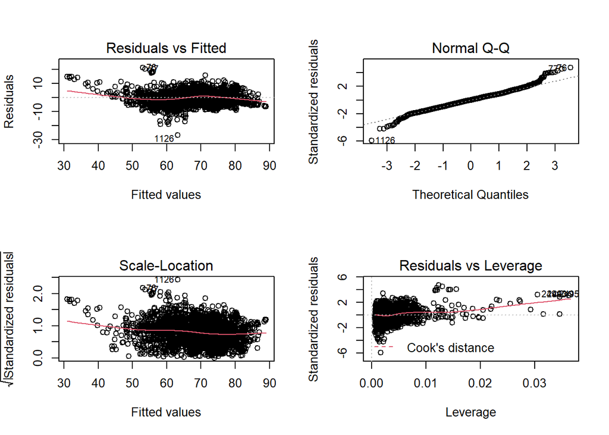

```r
par(mfrow = c(2, 2))
plot(model1)
```

```r
calc_rmse(le_tst_data$life_expectancy,
          predict(model1, newdata = le_tst_data))
```

```
## [1] 4.39782
```

```r
model2<-step(model1, data=non_cat_predictor_df, direction = "both", test="F")
```

```
## Start:  AIC=8003.26
## life_expectancy ~ schooling + bmi + alcohol + gdp + hiv_aids +
##     diphtheria + status
##
##              Df Sum of Sq   RSS    AIC   F value    Pr(>F)
## <none>                    54604 8003.3
## - alcohol     1      59.1 54663 8004.1    2.8412     0.092 .
## - status      1     933.9 55538 8045.9   44.9326 2.487e-11 ***
## - gdp         1    1666.1 56270 8080.5   80.1564 < 2.2e-16 ***
## - bmi         1    2849.8 57453 8135.3  137.1063 < 2.2e-16 ***
## - diphtheria  1    5048.8 59652 8234.3  242.9016 < 2.2e-16 ***
## - schooling   1   20820.0 75424 8852.4 1001.6563 < 2.2e-16 ***
## - hiv_aids    1   29079.2 83683 9126.2 1399.0111 < 2.2e-16 ***
## ---
## Signif. codes:  0 '***' 0.001 '**' 0.01 '*' 0.05 '.' 0.1 ' ' 1
```

```r
summary(model2)
```

```
##
## Call:
## lm(formula = life_expectancy ~ schooling + bmi + alcohol + gdp +
##     hiv_aids + diphtheria + status, data = non_cat_predictor_df)
##
## Residuals:
##      Min       1Q   Median       3Q      Max
## -26.9508  -2.8516  -0.0173   2.8691  21.4125
##
## Coefficients:
##                    Estimate Std. Error t value Pr(>|t|)
## (Intercept)       4.884e+01  5.877e-01  83.102  < 2e-16 ***
## schooling         1.275e+00  4.028e-02  31.649  < 2e-16 ***
## bmi               6.391e-02  5.458e-03  11.709  < 2e-16 ***
## alcohol          -4.988e-02  2.959e-02  -1.686    0.092 .
## gdp               6.939e-05  7.751e-06   8.953  < 2e-16 ***
## hiv_aids         -6.794e-01  1.816e-02 -37.403  < 2e-16 ***
## diphtheria        6.523e-02  4.186e-03  15.585  < 2e-16 ***
## statusDeveloping -2.146e+00  3.201e-01  -6.703 2.49e-11 ***
## ---
## Signif. codes:  0 '***' 0.001 '**' 0.01 '*' 0.05 '.' 0.1 ' ' 1
##
## Residual standard error: 4.559 on 2627 degrees of freedom
## Multiple R-squared:  0.7708, Adjusted R-squared:  0.7702
## F-statistic:  1262 on 7 and 2627 DF,  p-value: < 2.2e-16
```

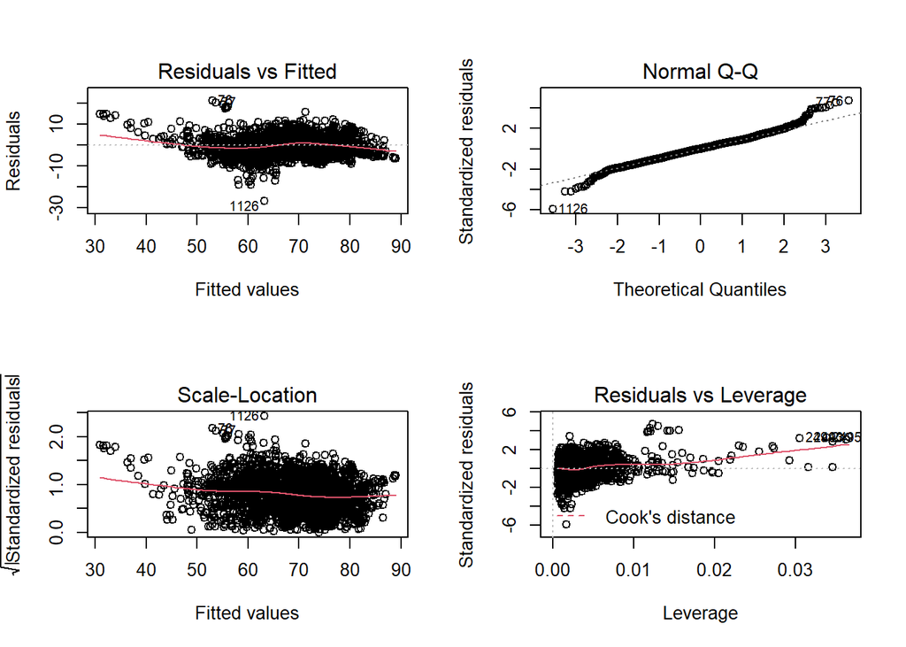

```r
par(mfrow = c(2, 2))
plot(model2)
```

```r
calc_rmse(le_tst_data$life_expectancy,
          predict(model2, newdata = le_tst_data))
```

```
## [1] 4.39782
```

```r
model1 <- lm(life_expectancy ~ schooling + bmi + gdp * status + hiv_aids + diphtheria, data = non_cat_predictor_df)
summary(model1)
```

```
##
## Call:
## lm(formula = life_expectancy ~ schooling + bmi + gdp * status +
##     hiv_aids + diphtheria, data = non_cat_predictor_df)
##
## Residuals:
##      Min       1Q   Median       3Q      Max
## -26.9932  -2.9250   0.0812   2.9494  20.7958
##
## Coefficients:
##                        Estimate Std. Error t value Pr(>|t|)
## (Intercept)           4.972e+01  6.390e-01  77.815  < 2e-16 ***
## schooling             1.234e+00  3.892e-02  31.715  < 2e-16 ***
## bmi                   6.029e-02  5.495e-03  10.972  < 2e-16 ***
## gdp                   4.706e-05  9.683e-06   4.860 1.24e-06 ***
## statusDeveloping     -2.742e+00  3.593e-01  -7.631 3.23e-14 ***
## hiv_aids             -6.809e-01  1.797e-02 -37.887  < 2e-16 ***
## diphtheria            6.451e-02  4.181e-03  15.430  < 2e-16 ***
## gdp:statusDeveloping  6.133e-05  1.588e-05   3.862 0.000115 ***
## ---
## Signif. codes:  0 '***' 0.001 '**' 0.01 '*' 0.05 '.' 0.1 ' ' 1
##
## Residual standard error: 4.549 on 2627 degrees of freedom
## Multiple R-squared:  0.7718, Adjusted R-squared:  0.7712
## F-statistic:  1269 on 7 and 2627 DF,  p-value: < 2.2e-16
```

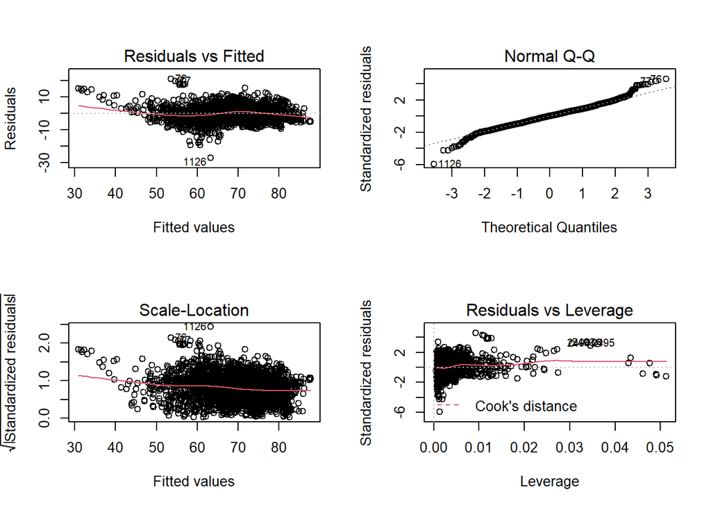

```r
par(mfrow = c(2, 2))
plot(model1)
```

```r
calc_rmse(le_tst_data$life_expectancy,
          predict(model1, newdata = le_tst_data))
```

```
## [1] 4.370292
```

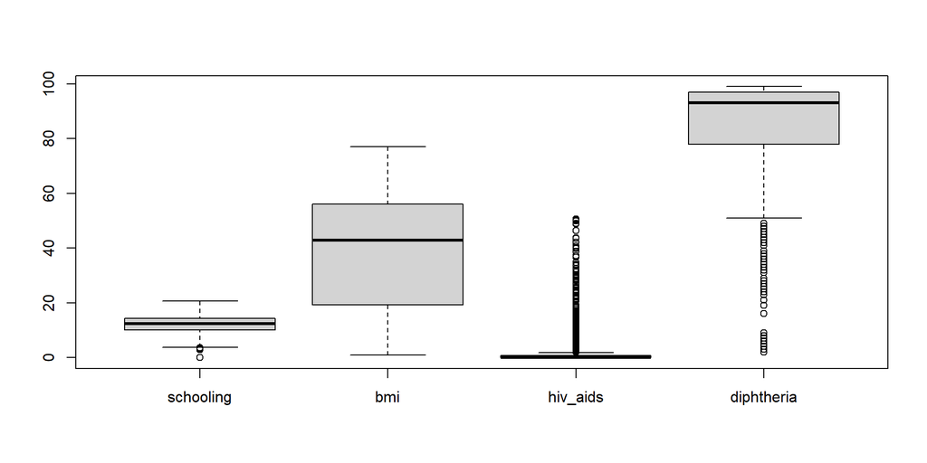

```r
bp_df <- subset(non_cat_predictor_df,
                select = c(schooling,bmi,hiv_aids,diphtheria))
boxplot(bp_df)
```

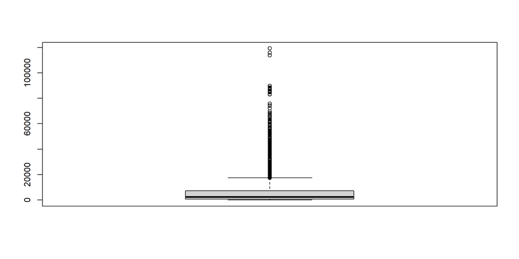

```r
boxplot(non_cat_predictor_df$gdp)
```

```r
model1 <- lm(life_expectancy ~ (schooling + bmi  + gdp + hiv_aids + diphtheria) * status, data = le_trn_data)
summary(model1)
```

```
##
## Call:
## lm(formula = life_expectancy ~ (schooling + bmi + gdp + hiv_aids +
##     diphtheria) * status, data = le_trn_data)
##
## Residuals:
##      Min       1Q   Median       3Q      Max
## -27.2444  -2.7806   0.0821   2.7248  21.0926
##
## Coefficients: (1 not defined because of singularities)
##                               Estimate Std. Error t value Pr(>|t|)
## (Intercept)                  6.400e+01  2.818e+00  22.708  < 2e-16 ***
## schooling                    8.323e-01  1.284e-01   6.483 1.07e-10 ***
## bmi                         -1.775e-02  1.238e-02  -1.434  0.15155
## gdp                          5.041e-05  9.706e-06   5.193 2.23e-07 ***
## hiv_aids                    -6.709e-01  1.778e-02 -37.737  < 2e-16 ***
## diphtheria                   2.186e-02  1.729e-02   1.264  0.20636
## statusDeveloping            -1.745e+01  2.852e+00  -6.118 1.09e-09 ***
## schooling:statusDeveloping   3.814e-01  1.349e-01   2.828  0.00472 **
## bmi:statusDeveloping         9.622e-02  1.378e-02   6.984 3.63e-12 ***
## gdp:statusDeveloping         4.708e-05  1.590e-05   2.962  0.00309 **
## hiv_aids:statusDeveloping           NA         NA      NA       NA
## diphtheria:statusDeveloping  4.321e-02  1.782e-02   2.425  0.01539 *
## ---
## Signif. codes:  0 '***' 0.001 '**' 0.01 '*' 0.05 '.' 0.1 ' ' 1
##
## Residual standard error: 4.489 on 2624 degrees of freedom
## Multiple R-squared:  0.778,  Adjusted R-squared:  0.7772
## F-statistic: 919.6 on 10 and 2624 DF,  p-value: < 2.2e-16
```

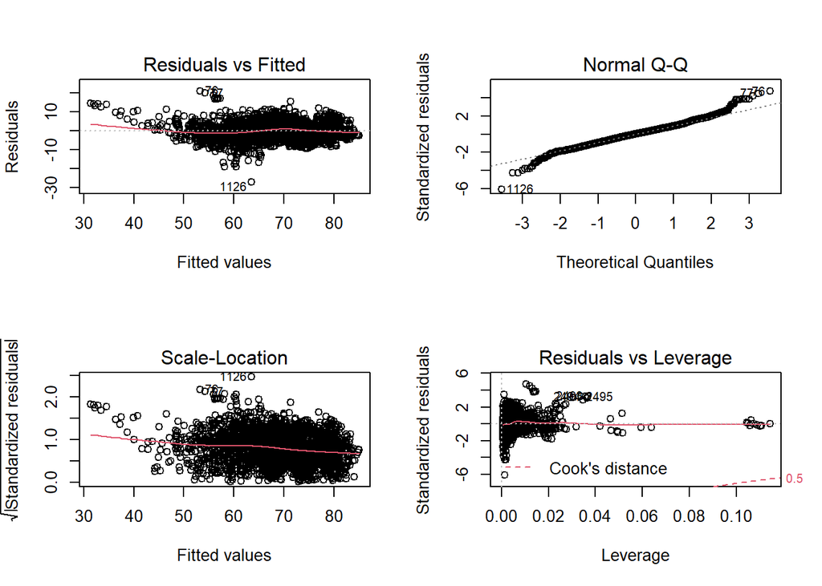

```r
par(mfrow = c(2, 2))
plot(model1)
```

```r
model2 <- step(model1, direction = "backward")
```

```
## Start:  AIC=7924.86
## life_expectancy ~ (schooling + bmi + gdp + hiv_aids + diphtheria) *
##     status
##
##
## Step:  AIC=7924.86
## life_expectancy ~ schooling + bmi + gdp + hiv_aids + diphtheria +
##     status + schooling:status + bmi:status + gdp:status + diphtheria:status
##
##                     Df Sum of Sq   RSS    AIC
## <none>                           52882 7924.9
## - diphtheria:status  1     118.5 53001 7928.8
## - schooling:status   1     161.2 53044 7930.9
## - gdp:status         1     176.8 53059 7931.6
## - bmi:status         1     982.9 53865 7971.4
## - hiv_aids           1   28699.7 81582 9065.2
```

```r
summary(model2)
```

```
##
## Call:
## lm(formula = life_expectancy ~ schooling + bmi + gdp + hiv_aids +
##     diphtheria + status + schooling:status + bmi:status + gdp:status +
##     diphtheria:status, data = le_trn_data)
##
## Residuals:
##      Min       1Q   Median       3Q      Max
## -27.2444  -2.7806   0.0821   2.7248  21.0926
##
## Coefficients:
##                               Estimate Std. Error t value Pr(>|t|)
## (Intercept)                  6.400e+01  2.818e+00  22.708  < 2e-16 ***
## schooling                    8.323e-01  1.284e-01   6.483 1.07e-10 ***
## bmi                         -1.775e-02  1.238e-02  -1.434  0.15155
## gdp                          5.041e-05  9.706e-06   5.193 2.23e-07 ***
## hiv_aids                    -6.709e-01  1.778e-02 -37.737  < 2e-16 ***
## diphtheria                   2.186e-02  1.729e-02   1.264  0.20636
## statusDeveloping            -1.745e+01  2.852e+00  -6.118 1.09e-09 ***
## schooling:statusDeveloping   3.814e-01  1.349e-01   2.828  0.00472 **
## bmi:statusDeveloping         9.622e-02  1.378e-02   6.984 3.63e-12 ***
## gdp:statusDeveloping         4.708e-05  1.590e-05   2.962  0.00309 **
## diphtheria:statusDeveloping  4.321e-02  1.782e-02   2.425  0.01539 *
## ---
## Signif. codes:  0 '***' 0.001 '**' 0.01 '*' 0.05 '.' 0.1 ' ' 1
##
## Residual standard error: 4.489 on 2624 degrees of freedom
## Multiple R-squared:  0.778,  Adjusted R-squared:  0.7772
## F-statistic: 919.6 on 10 and 2624 DF,  p-value: < 2.2e-16
```

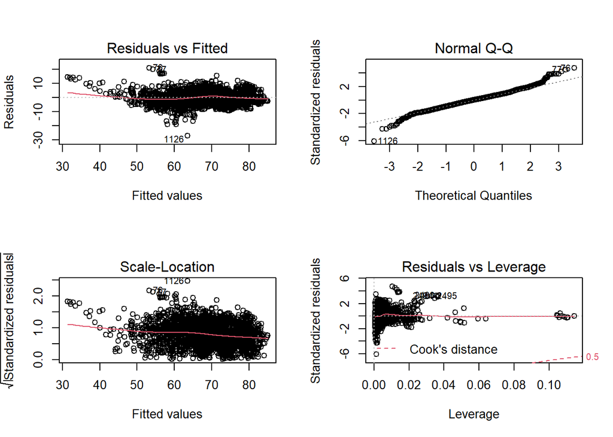

```r
par(mfrow = c(2, 2))
plot(model2)
```

```r
library(leaps)
```

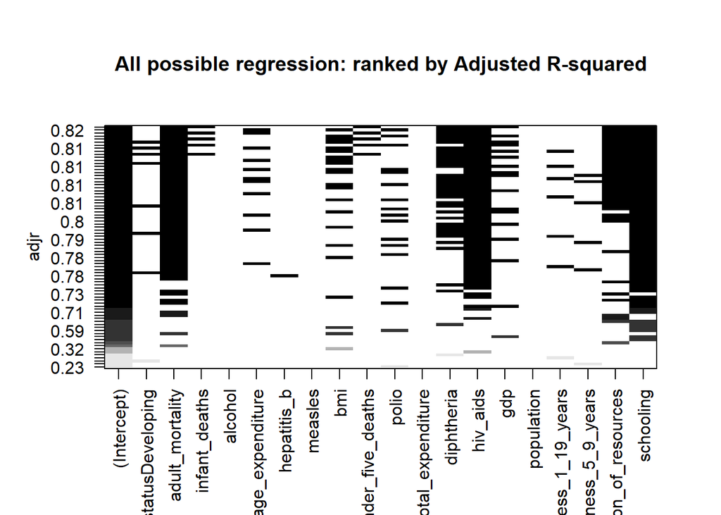

```r
regs <- regsubsets(life_expectancy ~ ., data = non_cat_predictor_df, nbest=10)
plot(regs,
     scale="adjr",
     main="All possible regression: ranked by Adjusted R-squared")
```

```r
model1 <- lm(life_expectancy ~ adult_mortality + bmi + hiv_aids +
               income_composition_of_resources + schooling, data = le_trn_data)
summary(model1)
```

```
##
## Call:
## lm(formula = life_expectancy ~ adult_mortality + bmi + hiv_aids +
##     income_composition_of_resources + schooling, data = le_trn_data)
##
## Residuals:
##      Min       1Q   Median       3Q      Max
## -21.5054  -2.1955  -0.1338   2.2222  23.3580
##
## Coefficients:
##                                   Estimate Std. Error t value Pr(>|t|)
## (Intercept)                     53.8491547  0.4361749 123.458   <2e-16 ***
## adult_mortality                 -0.0201389  0.0008887 -22.662   <2e-16 ***
## bmi                              0.0504595  0.0052085   9.688   <2e-16 ***
## hiv_aids                        -0.4867176  0.0191328 -25.439   <2e-16 ***
## income_composition_of_resources  9.0596858  0.6923758  13.085   <2e-16 ***
## schooling                        0.9977424  0.0451093  22.118   <2e-16 ***
## ---
## Signif. codes:  0 '***' 0.001 '**' 0.01 '*' 0.05 '.' 0.1 ' ' 1
##
## Residual standard error: 4.322 on 2629 degrees of freedom
## Multiple R-squared:  0.7938, Adjusted R-squared:  0.7934
## F-statistic:  2024 on 5 and 2629 DF,  p-value: < 2.2e-16
```

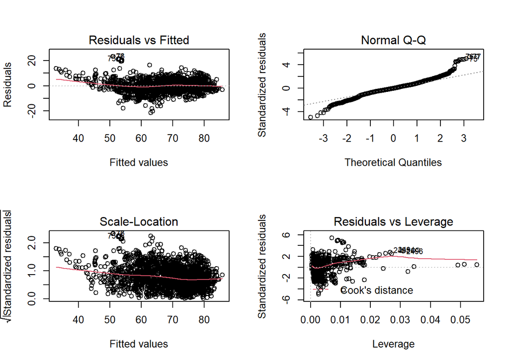

```r
par(mfrow = c(2, 2))
plot(model1)
```

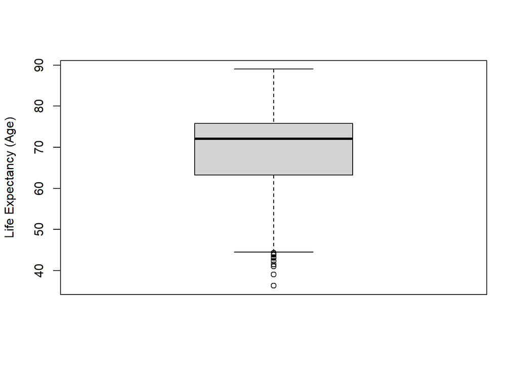

```r
boxplot(le_trn_data$life_expectancy, ylab = "Life Expectancy (Age)")
```

```r
outliers_out <- boxplot(le_trn_data$life_expectancy, plot = F)$out # untuk mendaptkan outlier
life_clean <- le_trn_data[-which(le_trn_data$life_expectancy %in% outliers_out), ]
nrow(life_clean)
```

```
## [1] 2624
```

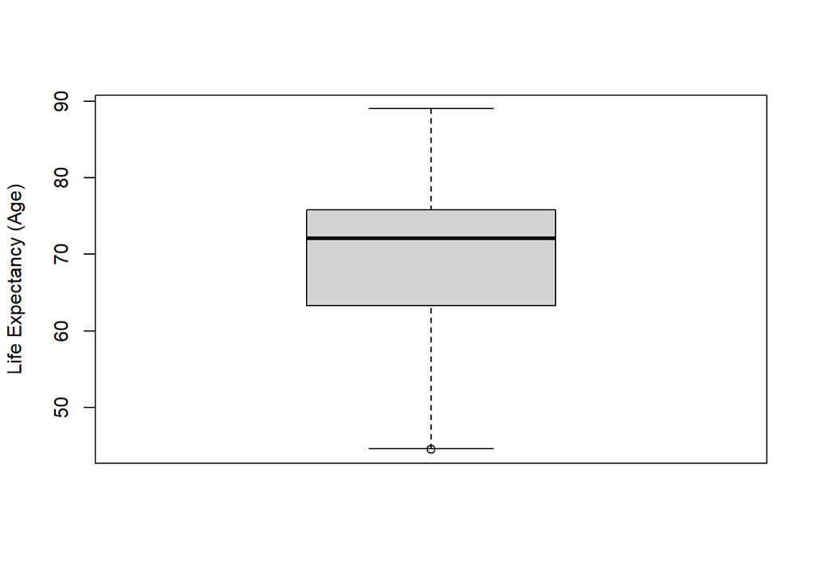

```r
boxplot(life_clean$life_expectancy, ylab = "Life Expectancy (Age)") #
```

```r
model1 <- lm(life_expectancy ~ adult_mortality + bmi + hiv_aids +
               income_composition_of_resources + schooling, data = life_clean)
summary(model1)
```

```
##
## Call:
## lm(formula = life_expectancy ~ adult_mortality + bmi + hiv_aids +
##     income_composition_of_resources + schooling, data = life_clean)
##
## Residuals:
##      Min       1Q   Median       3Q      Max
## -18.1504  -2.2166  -0.1487   2.2184  23.1675
##
## Coefficients:
##                                   Estimate Std. Error t value Pr(>|t|)
## (Intercept)                     53.9791795  0.4307309 125.320   <2e-16 ***
## adult_mortality                 -0.0197288  0.0008879 -22.219   <2e-16 ***
## bmi                              0.0504382  0.0051161   9.859   <2e-16 ***
## hiv_aids                        -0.4920254  0.0190763 -25.792   <2e-16 ***
## income_composition_of_resources  8.8965947  0.6799516  13.084   <2e-16 ***
## schooling                        0.9944462  0.0442962  22.450   <2e-16 ***
## ---
## Signif. codes:  0 '***' 0.001 '**' 0.01 '*' 0.05 '.' 0.1 ' ' 1
##
## Residual standard error: 4.242 on 2618 degrees of freedom
## Multiple R-squared:  0.7952, Adjusted R-squared:  0.7948
## F-statistic:  2033 on 5 and 2618 DF,  p-value: < 2.2e-16
```

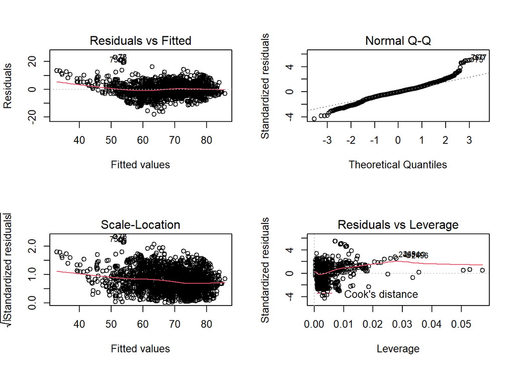

```r
par(mfrow = c(2, 2))
plot(model1)
```

```r
sig_linear_model <- lm(life_expectancy ~  adult_mortality +
                         under_five_deaths + bmi + diphtheria + hiv_aids + gdp +
                         income_composition_of_resources + schooling + status,
                       data = life_clean)
summary(sig_linear_model)
```

```
##
## Call:
## lm(formula = life_expectancy ~ adult_mortality + under_five_deaths +
##     bmi + diphtheria + hiv_aids + gdp + income_composition_of_resources +
##     schooling + status, data = life_clean)
##
## Residuals:
##      Min       1Q   Median       3Q      Max
## -18.0050  -2.3594  -0.1452   2.3826  18.8654
##
## Coefficients:
##                                   Estimate Std. Error t value Pr(>|t|)
## (Intercept)                      5.434e+01  5.799e-01  93.714  < 2e-16 ***
## adult_mortality                 -1.819e-02  8.404e-04 -21.643  < 2e-16 ***
## under_five_deaths               -2.498e-03  5.253e-04  -4.754 2.10e-06 ***
## bmi                              4.283e-02  4.863e-03   8.807  < 2e-16 ***
## diphtheria                       5.252e-02  3.717e-03  14.131  < 2e-16 ***
## hiv_aids                        -4.950e-01  1.794e-02 -27.587  < 2e-16 ***
## gdp                              4.778e-05  6.855e-06   6.970 4.00e-12 ***
## income_composition_of_resources  6.912e+00  6.522e-01  10.598  < 2e-16 ***
## schooling                        7.872e-01  4.347e-02  18.109  < 2e-16 ***
## statusDeveloping                -1.412e+00  2.538e-01  -5.563 2.92e-08 ***
## ---
## Signif. codes:  0 '***' 0.001 '**' 0.01 '*' 0.05 '.' 0.1 ' ' 1
##
## Residual standard error: 3.987 on 2614 degrees of freedom
## Multiple R-squared:  0.8193, Adjusted R-squared:  0.8187
## F-statistic:  1317 on 9 and 2614 DF,  p-value: < 2.2e-16
```

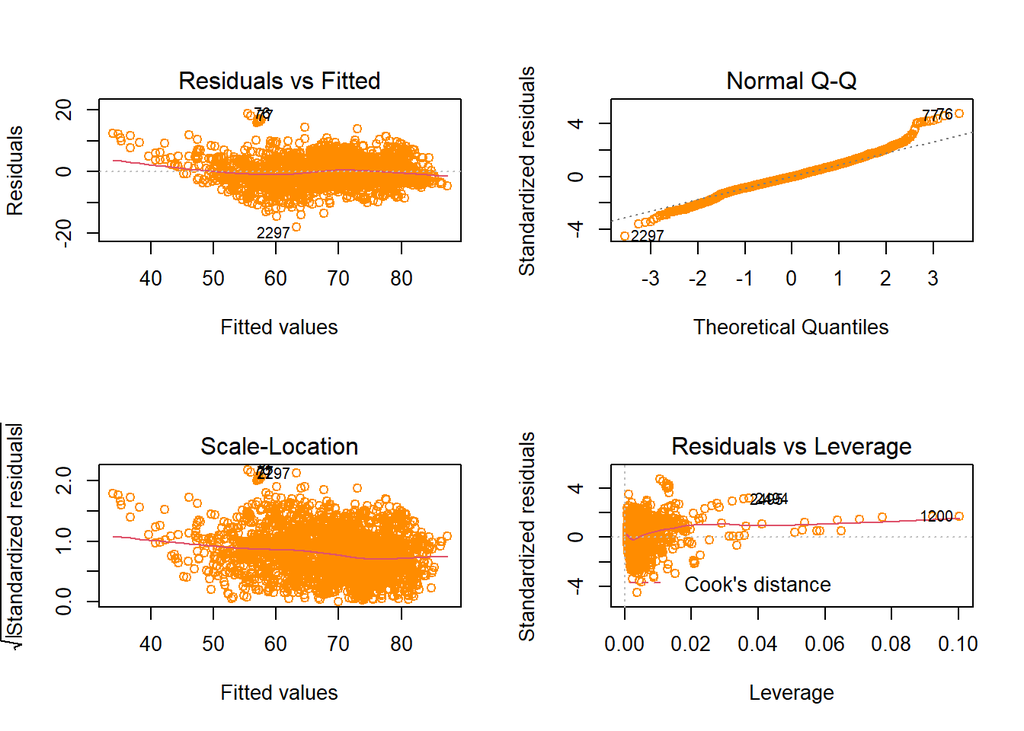

```r
par(mfrow = c(2, 2))
plot(sig_linear_model, col="darkorange", )
```

```r
full_model <- lm(life_expectancy ~ ., data = subset(life_clean, select = -c(year, country, continent, region)))
```

```r
aic_model <- step(full_model, direction = "both")
```

```
## Start:  AIC=7118.86
## life_expectancy ~ status + adult_mortality + infant_deaths +
##     alcohol + percentage_expenditure + hepatitis_b + measles +
##     bmi + under_five_deaths + polio + total_expenditure + diphtheria +
##     hiv_aids + gdp + population + thinness_1_19_years + thinness_5_9_years +
##     income_composition_of_resources + schooling
##
##                                   Df Sum of Sq   RSS    AIC
## - thinness_5_9_years               1       0.2 38956 7116.9
## - hepatitis_b                      1       0.5 38957 7116.9
## - population                       1       2.6 38959 7117.0
## - alcohol                          1      26.2 38982 7118.6
## <none>                                         38956 7118.9
## - thinness_1_19_years              1      34.7 38991 7119.2
## - total_expenditure                1      39.9 38996 7119.5
## - measles                          1      60.9 39017 7121.0
## - percentage_expenditure           1      66.0 39022 7121.3
## - gdp                              1      97.6 39054 7123.4
## - status                           1     283.0 39239 7135.9
## - polio                            1     432.3 39388 7145.8
## - diphtheria                       1     625.6 39582 7158.7
## - bmi                              1     775.8 39732 7168.6
## - income_composition_of_resources  1    1407.5 40364 7210.0
## - infant_deaths                    1    1640.7 40597 7225.1
## - under_five_deaths                1    1708.9 40665 7229.5
## - schooling                        1    4021.5 42978 7374.6
## - adult_mortality                  1    6958.3 45914 7548.1
## - hiv_aids                         1   11167.2 50123 7778.2
##
## Step:  AIC=7116.87
## life_expectancy ~ status + adult_mortality + infant_deaths +
##     alcohol + percentage_expenditure + hepatitis_b + measles +
##     bmi + under_five_deaths + polio + total_expenditure + diphtheria +
##     hiv_aids + gdp + population + thinness_1_19_years + income_composition_of_resources +
##     schooling
##
##                                   Df Sum of Sq   RSS    AIC
## - hepatitis_b                      1       0.5 38957 7114.9
## - population                       1       2.6 38959 7115.0
## - alcohol                          1      26.3 38983 7116.6
```

[output cut: 87 more lines]

```
## + thinness_5_9_years               1       0.4 38986 7114.9
## - measles                          1      61.9 39049 7115.1
## - percentage_expenditure           1      71.4 39058 7115.7
## - gdp                              1      93.2 39080 7117.2
## - thinness_1_19_years              1     197.5 39184 7124.2
## - status                           1     416.7 39403 7138.8
## - polio                            1     443.1 39430 7140.6
## - diphtheria                       1     729.0 39716 7159.5
## - bmi                              1     790.0 39777 7163.6
## - income_composition_of_resources  1    1415.8 40403 7204.5
## - infant_deaths                    1    1686.2 40673 7222.0
## - under_five_deaths                1    1717.2 40704 7224.0
## - schooling                        1    4406.1 43393 7391.9
## - adult_mortality                  1    6954.9 45942 7541.7
## - hiv_aids                         1   11179.4 50166 7772.5
```

```r
summary(aic_model)
```

```
##
## Call:
## lm(formula = life_expectancy ~ status + adult_mortality + infant_deaths +
##     percentage_expenditure + measles + bmi + under_five_deaths +
##     polio + total_expenditure + diphtheria + hiv_aids + gdp +
##     thinness_1_19_years + income_composition_of_resources + schooling,
##     data = subset(life_clean, select = -c(year, country, continent,
##         region)))
##
## Residuals:
##      Min       1Q   Median       3Q      Max
## -17.5984  -2.3398  -0.1235   2.2619  17.5405
##
## Coefficients:
##                                   Estimate Std. Error t value Pr(>|t|)
## (Intercept)                      5.524e+01  6.431e-01  85.891  < 2e-16 ***
## statusDeveloping                -1.346e+00  2.550e-01  -5.280 1.40e-07 ***
## adult_mortality                 -1.766e-02  8.189e-04 -21.570  < 2e-16 ***
## infant_deaths                    8.870e-02  8.351e-03  10.621  < 2e-16 ***
## percentage_expenditure           1.649e-04  7.544e-05   2.186 0.028931 *
## measles                         -1.548e-05  7.605e-06  -2.036 0.041890 *
## bmi                              3.646e-02  5.016e-03   7.270 4.74e-13 ***
## under_five_deaths               -6.602e-02  6.160e-03 -10.718  < 2e-16 ***
## polio                            2.482e-02  4.559e-03   5.445 5.68e-08 ***
## total_expenditure                5.908e-02  3.383e-02   1.746 0.080870 .
## diphtheria                       3.168e-02  4.536e-03   6.983 3.64e-12 ***
## hiv_aids                        -4.802e-01  1.756e-02 -27.347  < 2e-16 ***
## gdp                              2.909e-05  1.165e-05   2.496 0.012609 *
## thinness_1_19_years             -8.538e-02  2.349e-02  -3.635 0.000283 ***
## income_composition_of_resources  6.227e+00  6.399e-01   9.732  < 2e-16 ***
## schooling                        7.365e-01  4.290e-02  17.168  < 2e-16 ***
## ---
## Signif. codes:  0 '***' 0.001 '**' 0.01 '*' 0.05 '.' 0.1 ' ' 1
##
## Residual standard error: 3.866 on 2608 degrees of freedom
## Multiple R-squared:  0.8305, Adjusted R-squared:  0.8295
## F-statistic: 851.7 on 15 and 2608 DF,  p-value: < 2.2e-16
```

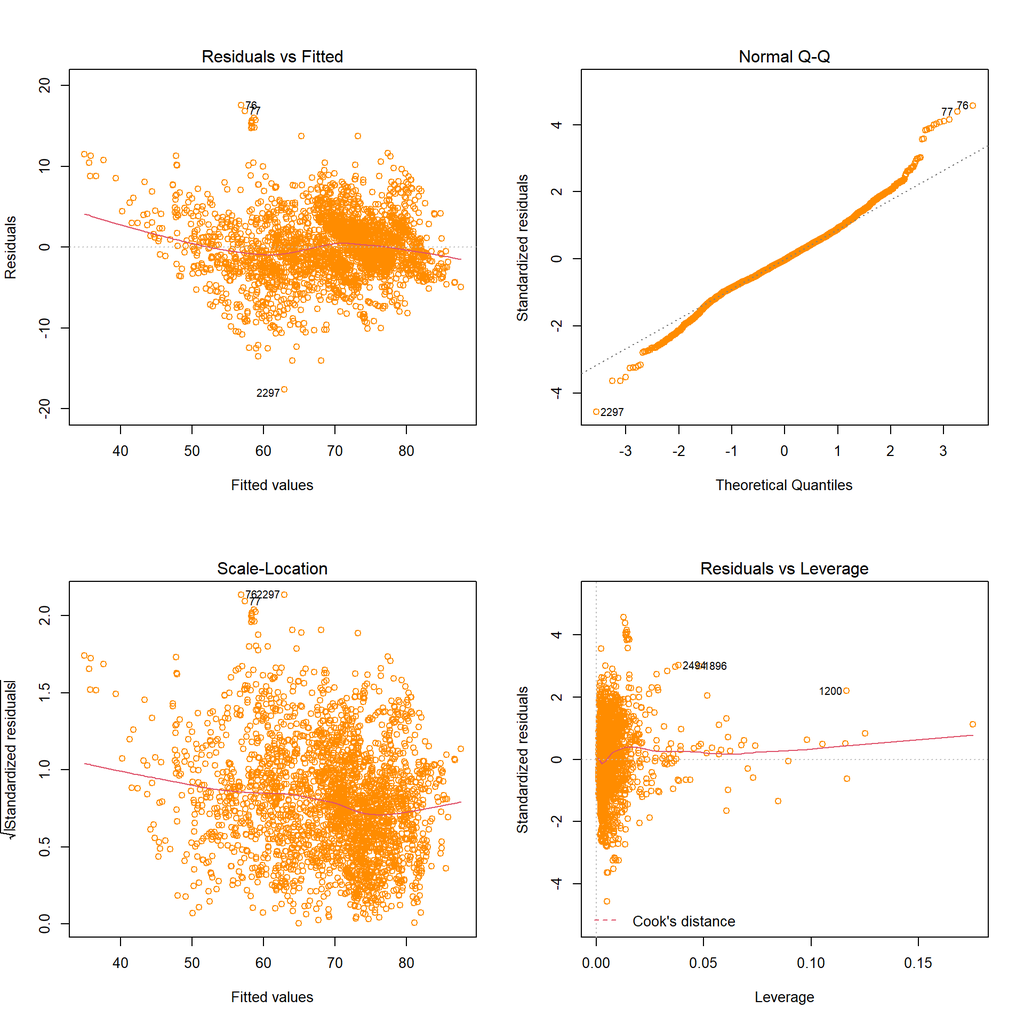

```r
par(mfrow = c(2, 2))
plot(aic_model, col="darkorange", )
```

```r
bic_model <- step(full_model, direction = "backward")
```

```
## Start:  AIC=7118.86
## life_expectancy ~ status + adult_mortality + infant_deaths +
##     alcohol + percentage_expenditure + hepatitis_b + measles +
##     bmi + under_five_deaths + polio + total_expenditure + diphtheria +
##     hiv_aids + gdp + population + thinness_1_19_years + thinness_5_9_years +
##     income_composition_of_resources + schooling
##
##                                   Df Sum of Sq   RSS    AIC
## - thinness_5_9_years               1       0.2 38956 7116.9
## - hepatitis_b                      1       0.5 38957 7116.9
## - population                       1       2.6 38959 7117.0
## - alcohol                          1      26.2 38982 7118.6
## <none>                                         38956 7118.9
## - thinness_1_19_years              1      34.7 38991 7119.2
## - total_expenditure                1      39.9 38996 7119.5
## - measles                          1      60.9 39017 7121.0
## - percentage_expenditure           1      66.0 39022 7121.3
## - gdp                              1      97.6 39054 7123.4
## - status                           1     283.0 39239 7135.9
## - polio                            1     432.3 39388 7145.8
## - diphtheria                       1     625.6 39582 7158.7
## - bmi                              1     775.8 39732 7168.6
## - income_composition_of_resources  1    1407.5 40364 7210.0
## - infant_deaths                    1    1640.7 40597 7225.1
## - under_five_deaths                1    1708.9 40665 7229.5
## - schooling                        1    4021.5 42978 7374.6
## - adult_mortality                  1    6958.3 45914 7548.1
## - hiv_aids                         1   11167.2 50123 7778.2
##
## Step:  AIC=7116.87
## life_expectancy ~ status + adult_mortality + infant_deaths +
##     alcohol + percentage_expenditure + hepatitis_b + measles +
##     bmi + under_five_deaths + polio + total_expenditure + diphtheria +
##     hiv_aids + gdp + population + thinness_1_19_years + income_composition_of_resources +
##     schooling
##
##                                   Df Sum of Sq   RSS    AIC
## - hepatitis_b                      1       0.5 38957 7114.9
## - population                       1       2.6 38959 7115.0
## - alcohol                          1      26.3 38983 7116.6
```

[output cut: 77 more lines]

```
## - total_expenditure                1      45.6 39032 7114.0
## - measles                          1      61.9 39049 7115.1
## - percentage_expenditure           1      71.4 39058 7115.7
## - gdp                              1      93.2 39080 7117.2
## - thinness_1_19_years              1     197.5 39184 7124.2
## - status                           1     416.7 39403 7138.8
## - polio                            1     443.1 39430 7140.6
## - diphtheria                       1     729.0 39716 7159.5
## - bmi                              1     790.0 39777 7163.6
## - income_composition_of_resources  1    1415.8 40403 7204.5
## - infant_deaths                    1    1686.2 40673 7222.0
## - under_five_deaths                1    1717.2 40704 7224.0
## - schooling                        1    4406.1 43393 7391.9
## - adult_mortality                  1    6954.9 45942 7541.7
## - hiv_aids                         1   11179.4 50166 7772.5
```

```r
summary(bic_model)
```

```
##
## Call:
## lm(formula = life_expectancy ~ status + adult_mortality + infant_deaths +
##     percentage_expenditure + measles + bmi + under_five_deaths +
##     polio + total_expenditure + diphtheria + hiv_aids + gdp +
##     thinness_1_19_years + income_composition_of_resources + schooling,
##     data = subset(life_clean, select = -c(year, country, continent,
##         region)))
##
## Residuals:
##      Min       1Q   Median       3Q      Max
## -17.5984  -2.3398  -0.1235   2.2619  17.5405
##
## Coefficients:
##                                   Estimate Std. Error t value Pr(>|t|)
## (Intercept)                      5.524e+01  6.431e-01  85.891  < 2e-16 ***
## statusDeveloping                -1.346e+00  2.550e-01  -5.280 1.40e-07 ***
## adult_mortality                 -1.766e-02  8.189e-04 -21.570  < 2e-16 ***
## infant_deaths                    8.870e-02  8.351e-03  10.621  < 2e-16 ***
## percentage_expenditure           1.649e-04  7.544e-05   2.186 0.028931 *
## measles                         -1.548e-05  7.605e-06  -2.036 0.041890 *
## bmi                              3.646e-02  5.016e-03   7.270 4.74e-13 ***
## under_five_deaths               -6.602e-02  6.160e-03 -10.718  < 2e-16 ***
## polio                            2.482e-02  4.559e-03   5.445 5.68e-08 ***
## total_expenditure                5.908e-02  3.383e-02   1.746 0.080870 .
## diphtheria                       3.168e-02  4.536e-03   6.983 3.64e-12 ***
## hiv_aids                        -4.802e-01  1.756e-02 -27.347  < 2e-16 ***
## gdp                              2.909e-05  1.165e-05   2.496 0.012609 *
## thinness_1_19_years             -8.538e-02  2.349e-02  -3.635 0.000283 ***
## income_composition_of_resources  6.227e+00  6.399e-01   9.732  < 2e-16 ***
## schooling                        7.365e-01  4.290e-02  17.168  < 2e-16 ***
## ---
## Signif. codes:  0 '***' 0.001 '**' 0.01 '*' 0.05 '.' 0.1 ' ' 1
##
## Residual standard error: 3.866 on 2608 degrees of freedom
## Multiple R-squared:  0.8305, Adjusted R-squared:  0.8295
## F-statistic: 851.7 on 15 and 2608 DF,  p-value: < 2.2e-16
```

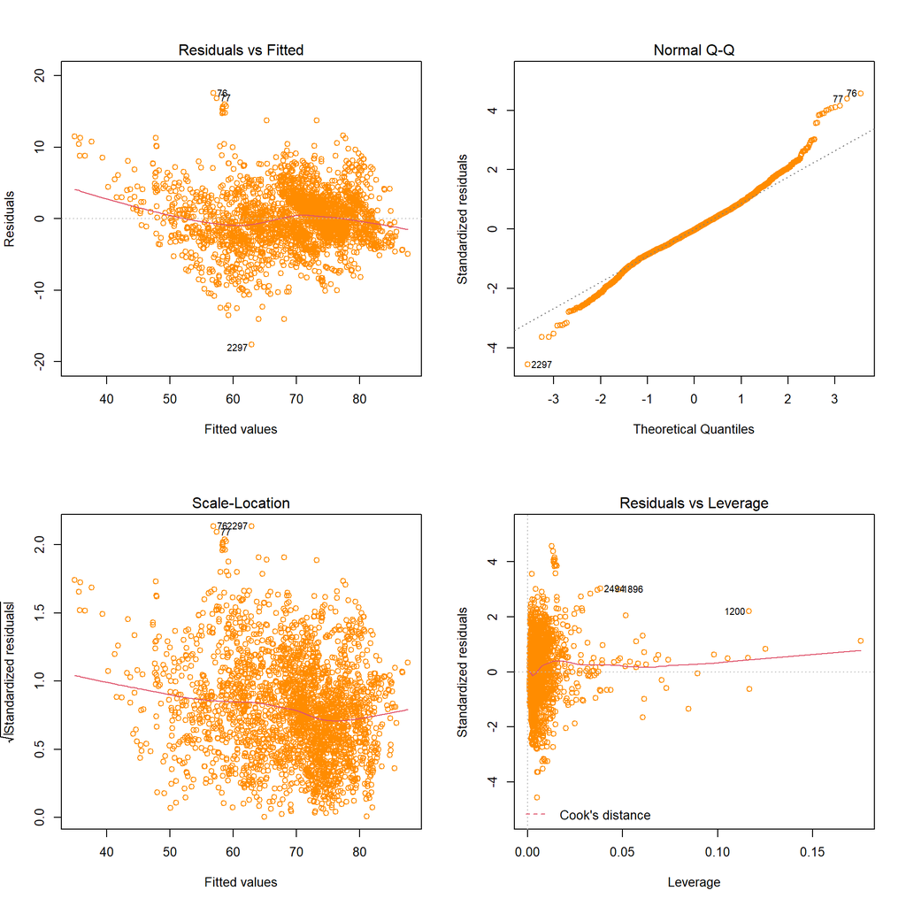

```r
par(mfrow = c(2, 2))
plot(bic_model, col="darkorange", )
```

```r
clean_bic <- lm(life_expectancy ~ status + adult_mortality + infant_deaths +
     + bmi + under_five_deaths +
    polio + diphtheria + hiv_aids + income_composition_of_resources + schooling,
    data = life_clean)
summary(clean_bic)
```

```
##
## Call:
## lm(formula = life_expectancy ~ status + adult_mortality + infant_deaths +
##     +bmi + under_five_deaths + polio + diphtheria + hiv_aids +
##     income_composition_of_resources + schooling, data = life_clean)
##
## Residuals:
##      Min       1Q   Median       3Q      Max
## -17.7994  -2.2965  -0.1041   2.2529  18.5435
##
## Coefficients:
##                                   Estimate Std. Error t value Pr(>|t|)
## (Intercept)                     55.0840506  0.5905404  93.277  < 2e-16 ***
## statusDeveloping                -2.1741396  0.2398023  -9.066  < 2e-16 ***
## adult_mortality                 -0.0179869  0.0008269 -21.752  < 2e-16 ***
## infant_deaths                    0.0846174  0.0084069  10.065  < 2e-16 ***
## bmi                              0.0446784  0.0047838   9.339  < 2e-16 ***
## under_five_deaths               -0.0644595  0.0061863 -10.420  < 2e-16 ***
## polio                            0.0248476  0.0046206   5.378 8.22e-08 ***
## diphtheria                       0.0314429  0.0045996   6.836 1.01e-11 ***
## hiv_aids                        -0.4799068  0.0176931 -27.124  < 2e-16 ***
## income_composition_of_resources  6.8176464  0.6401068  10.651  < 2e-16 ***
## schooling                        0.7794565  0.0429254  18.158  < 2e-16 ***
## ---
## Signif. codes:  0 '***' 0.001 '**' 0.01 '*' 0.05 '.' 0.1 ' ' 1
##
## Residual standard error: 3.924 on 2613 degrees of freedom
## Multiple R-squared:  0.825,  Adjusted R-squared:  0.8244
## F-statistic:  1232 on 10 and 2613 DF,  p-value: < 2.2e-16
```

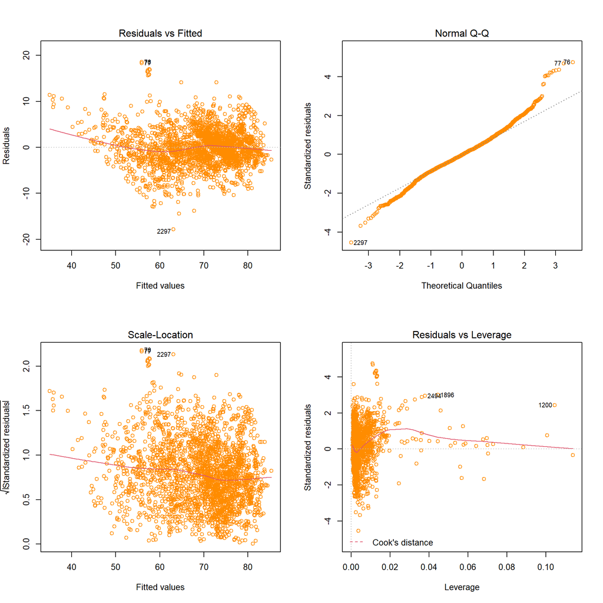

```r
par(mfrow = c(2, 2))
plot(clean_bic, col="darkorange", )
```

```r
bc <- boxcox(clean_bic, lambda = seq(-3, 3))
```

[figure not shown]

```r
best.lam <- bc$x[which(bc$y==max(bc$y))]
```

```r
life_clean <- life_clean[which(life_clean$life_expectancy > 50), ]
nrow(life_clean)
```

```
## [1] 2525
```

```r
clean_bic <- lm(life_expectancy ~ status + adult_mortality + infant_deaths +
     + bmi + under_five_deaths +
    polio + diphtheria + hiv_aids + income_composition_of_resources + schooling,
    data = life_clean)
summary(clean_bic)
```

```
##
## Call:
## lm(formula = life_expectancy ~ status + adult_mortality + infant_deaths +
##     +bmi + under_five_deaths + polio + diphtheria + hiv_aids +
##     income_composition_of_resources + schooling, data = life_clean)
##
## Residuals:
##      Min       1Q   Median       3Q      Max
## -14.3121  -2.2247  -0.1143   2.1593  17.4907
##
## Coefficients:
##                                   Estimate Std. Error t value Pr(>|t|)
## (Intercept)                     57.2772489  0.6003860  95.401  < 2e-16 ***
## statusDeveloping                -2.2759834  0.2309374  -9.855  < 2e-16 ***
## adult_mortality                 -0.0194412  0.0009306 -20.891  < 2e-16 ***
## infant_deaths                    0.0693023  0.0098036   7.069 2.01e-12 ***
## bmi                              0.0389316  0.0046108   8.444  < 2e-16 ***
## under_five_deaths               -0.0533229  0.0072975  -7.307 3.65e-13 ***
## polio                            0.0220567  0.0045025   4.899 1.03e-06 ***
## diphtheria                       0.0261304  0.0044883   5.822 6.56e-09 ***
## hiv_aids                        -0.5626863  0.0278559 -20.200  < 2e-16 ***
## income_composition_of_resources  6.4577600  0.6205748  10.406  < 2e-16 ***
## schooling                        0.7347332  0.0419489  17.515  < 2e-16 ***
## ---
## Signif. codes:  0 '***' 0.001 '**' 0.01 '*' 0.05 '.' 0.1 ' ' 1
##
## Residual standard error: 3.757 on 2514 degrees of freedom
## Multiple R-squared:  0.8036, Adjusted R-squared:  0.8028
## F-statistic:  1029 on 10 and 2514 DF,  p-value: < 2.2e-16
```

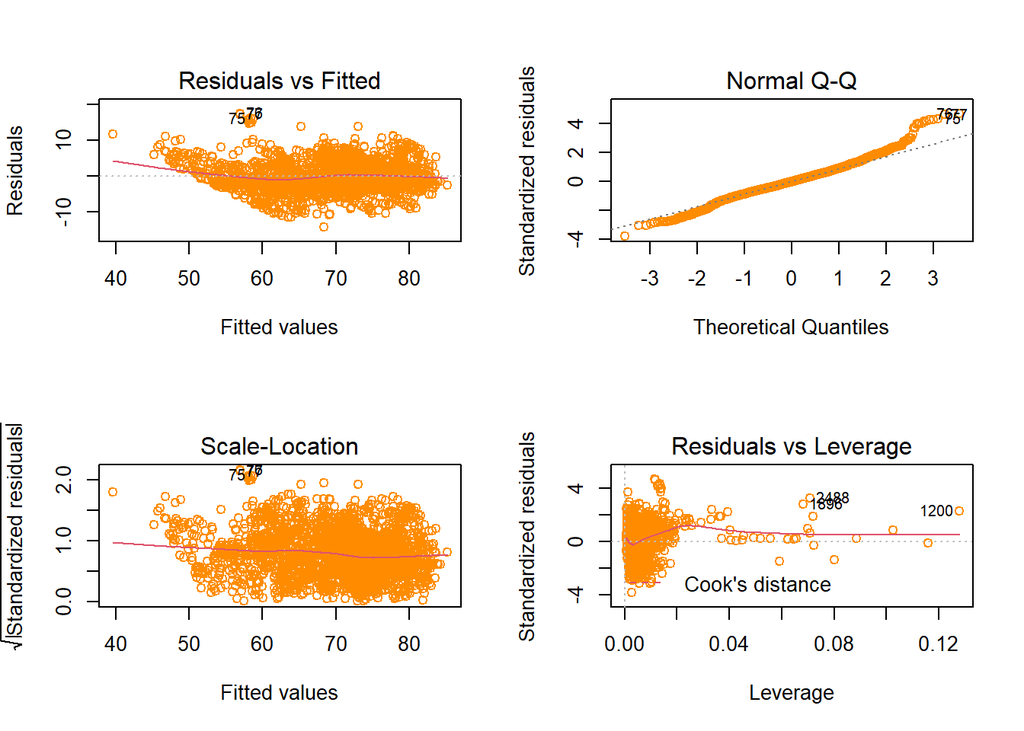

```r
par(mfrow = c(2, 2))
plot(clean_bic, col="darkorange", )
```

```r
life_clean1 <- subset(life_clean, select = -c(year, country, continent, region))
clean_full <- lm(formula = life_expectancy ~ ., data = life_clean1)
clean_none <- lm(formula = life_expectancy ~ 1, data = life_clean1)
```

```r
clean_backward <- step(clean_full, direction = "backward")
```

```
## Start:  AIC=6602.45
## life_expectancy ~ status + adult_mortality + infant_deaths +
##     alcohol + percentage_expenditure + hepatitis_b + measles +
##     bmi + under_five_deaths + polio + total_expenditure + diphtheria +
##     hiv_aids + gdp + population + thinness_1_19_years + thinness_5_9_years +
##     income_composition_of_resources + schooling
##
##                                   Df Sum of Sq   RSS    AIC
## - hepatitis_b                      1       0.3 33962 6600.5
## - population                       1       1.6 33963 6600.6
## - thinness_5_9_years               1       3.1 33965 6600.7
## <none>                                         33962 6602.4
## - thinness_1_19_years              1      39.9 34001 6603.4
## - total_expenditure                1      59.0 34021 6604.8
## - alcohol                          1      63.0 34025 6605.1
## - percentage_expenditure           1      71.7 34033 6605.8
## - measles                          1      77.2 34039 6606.2
## - gdp                              1      97.1 34059 6607.7
## - status                           1     266.3 34228 6620.2
## - polio                            1     316.2 34278 6623.8
## - diphtheria                       1     376.3 34338 6628.3
## - bmi                              1     458.3 34420 6634.3
## - infant_deaths                    1     945.7 34907 6669.8
## - under_five_deaths                1     979.2 34941 6672.2
## - income_composition_of_resources  1    1254.7 35216 6692.0
## - schooling                        1    3146.9 37108 6824.2
## - hiv_aids                         1    5616.3 39578 6986.9
## - adult_mortality                  1    5805.6 39767 6998.9
##
## Step:  AIC=6600.47
## life_expectancy ~ status + adult_mortality + infant_deaths +
##     alcohol + percentage_expenditure + measles + bmi + under_five_deaths +
##     polio + total_expenditure + diphtheria + hiv_aids + gdp +
##     population + thinness_1_19_years + thinness_5_9_years + income_composition_of_resources +
##     schooling
##
##                                   Df Sum of Sq   RSS    AIC
## - population                       1       1.6 33963 6598.6
## - thinness_5_9_years               1       3.1 33965 6598.7
## <none>                                         33962 6600.5
```

[output cut: 53 more lines]

```
## - alcohol                          1      64.2 34031 6599.6
## - percentage_expenditure           1      71.4 34038 6600.1
## - measles                          1      78.5 34045 6600.7
## - gdp                              1      98.2 34065 6602.1
## - thinness_1_19_years              1     245.9 34213 6613.1
## - status                           1     267.0 34234 6614.6
## - polio                            1     328.3 34295 6619.1
## - diphtheria                       1     462.5 34429 6629.0
## - bmi                              1     476.6 34443 6630.0
## - infant_deaths                    1     969.4 34936 6665.9
## - under_five_deaths                1     988.2 34955 6667.2
## - income_composition_of_resources  1    1253.2 35220 6686.3
## - schooling                        1    3177.0 37144 6820.6
## - hiv_aids                         1    5650.2 39617 6983.4
## - adult_mortality                  1    5825.7 39792 6994.5
```

```r
summary(clean_backward)
```

```
##
## Call:
## lm(formula = life_expectancy ~ status + adult_mortality + infant_deaths +
##     alcohol + percentage_expenditure + measles + bmi + under_five_deaths +
##     polio + total_expenditure + diphtheria + hiv_aids + gdp +
##     thinness_1_19_years + income_composition_of_resources + schooling,
##     data = life_clean1)
##
## Residuals:
##      Min       1Q   Median       3Q      Max
## -14.4795  -2.2931  -0.1227   2.1553  15.8087
##
## Coefficients:
##                                   Estimate Std. Error t value Pr(>|t|)
## (Intercept)                      5.753e+01  6.560e-01  87.700  < 2e-16 ***
## statusDeveloping                -1.176e+00  2.650e-01  -4.440 9.38e-06 ***
## adult_mortality                 -1.905e-02  9.186e-04 -20.740  < 2e-16 ***
## infant_deaths                    8.351e-02  9.871e-03   8.460  < 2e-16 ***
## alcohol                          5.539e-02  2.545e-02   2.176  0.02962 *
## percentage_expenditure           1.651e-04  7.191e-05   2.296  0.02178 *
## measles                         -2.092e-05  8.690e-06  -2.407  0.01615 *
## bmi                              2.858e-02  4.817e-03   5.932 3.40e-09 ***
## under_five_deaths               -6.225e-02  7.287e-03  -8.542  < 2e-16 ***
## polio                            2.176e-02  4.419e-03   4.923 9.06e-07 ***
## total_expenditure                6.932e-02  3.285e-02   2.110  0.03494 *
## diphtheria                       2.573e-02  4.403e-03   5.844 5.76e-09 ***
## hiv_aids                        -5.670e-01  2.776e-02 -20.425  < 2e-16 ***
## gdp                              2.992e-05  1.111e-05   2.693  0.00713 **
## thinness_1_19_years             -1.003e-01  2.353e-02  -4.261 2.11e-05 ***
## income_composition_of_resources  5.929e+00  6.163e-01   9.619  < 2e-16 ***
## schooling                        6.548e-01  4.275e-02  15.316  < 2e-16 ***
## ---
## Signif. codes:  0 '***' 0.001 '**' 0.01 '*' 0.05 '.' 0.1 ' ' 1
##
## Residual standard error: 3.68 on 2508 degrees of freedom
## Multiple R-squared:  0.812,  Adjusted R-squared:  0.8108
## F-statistic:   677 on 16 and 2508 DF,  p-value: < 2.2e-16
```

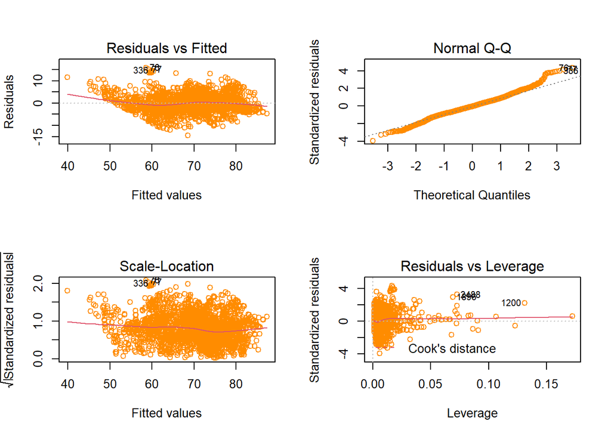

```r
par(mfrow = c(2, 2))
plot(clean_backward, col="darkorange")
```

```r
small_cleaner_backward <- lm(life_expectancy ~ status + adult_mortality + infant_deaths + bmi + under_five_deaths +
     total_expenditure + diphtheria + hiv_aids + gdp +
    thinness_1_19_years + income_composition_of_resources + schooling,
    data = life_clean1)

summary(small_cleaner_backward)
```

```
##
## Call:
## lm(formula = life_expectancy ~ status + adult_mortality + infant_deaths +
##     bmi + under_five_deaths + total_expenditure + diphtheria +
##     hiv_aids + gdp + thinness_1_19_years + income_composition_of_resources +
##     schooling, data = life_clean1)
##
## Residuals:
##      Min       1Q   Median       3Q      Max
## -14.4482  -2.2757  -0.1305   2.1693  16.6982
##
## Coefficients:
##                                   Estimate Std. Error t value Pr(>|t|)
## (Intercept)                      5.813e+01  6.432e-01  90.373  < 2e-16 ***
## statusDeveloping                -1.469e+00  2.441e-01  -6.015 2.06e-09 ***
## adult_mortality                 -1.893e-02  9.212e-04 -20.545  < 2e-16 ***
## infant_deaths                    7.881e-02  9.713e-03   8.114 7.55e-16 ***
## bmi                              2.921e-02  4.824e-03   6.055 1.61e-09 ***
## under_five_deaths               -5.938e-02  7.214e-03  -8.231 2.95e-16 ***
## total_expenditure                8.162e-02  3.293e-02   2.478   0.0133 *
## diphtheria                       3.854e-02  3.612e-03  10.670  < 2e-16 ***
## hiv_aids                        -5.681e-01  2.771e-02 -20.501  < 2e-16 ***
## gdp                              5.136e-05  6.387e-06   8.041 1.36e-15 ***
## thinness_1_19_years             -1.070e-01  2.302e-02  -4.646 3.56e-06 ***
## income_composition_of_resources  5.856e+00  6.201e-01   9.444  < 2e-16 ***
## schooling                        6.996e-01  4.184e-02  16.720  < 2e-16 ***
## ---
## Signif. codes:  0 '***' 0.001 '**' 0.01 '*' 0.05 '.' 0.1 ' ' 1
##
## Residual standard error: 3.707 on 2512 degrees of freedom
## Multiple R-squared:  0.809,  Adjusted R-squared:  0.8081
## F-statistic: 886.5 on 12 and 2512 DF,  p-value: < 2.2e-16
```

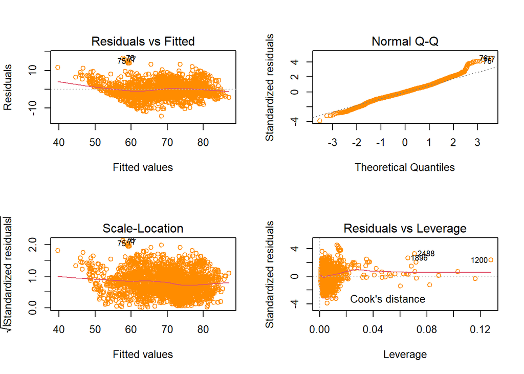

```r
par(mfrow = c(2, 2))
plot(small_cleaner_backward, col="darkorange")
```